# INN_Learner_Notebook_Full_code

Bank Churn Prediction

## Problem Statement

### Context

Businesses like banks which provide service have to worry about problem of 'Customer Churn' i.e. customers leaving and joining another service provider. It is important to understand which aspects of the service influence a customer's decision in this regard. Management can concentrate efforts on improvement of service, keeping in mind these priorities.

### Objective

You as a Data scientist with the bank need to build a neural network based classifier that can determine whether a customer will leave the bank or not in the next 6 months.

### Data Dictionary

- CustomerId: Unique ID which is assigned to each customer
- Surname: Last name of the customer
- CreditScore: It defines the credit history of the customer.
- Geography: A customer’s location
- Gender: It defines the Gender of the customer
- Age: Age of the customer
- Tenure: Number of years for which the customer has been with the bank
- NumOfProducts: refers to the number of products that a customer has purchased through the bank.
- Balance: Account balance
- HasCrCard: It is a categorical variable which decides whether the customer has credit card or not.
- EstimatedSalary: Estimated salary
- isActiveMember: Is is a categorical variable which decides whether the customer is active member of the bank or not ( Active member in the sense, using bank products regularly, making transactions etc )
- Exited : whether or not the customer left the bank within six month. It can take two values ** 0=No ( Customer did not leave the bank ) ** 1=Yes ( Customer left the bank )

## Importing necessary libraries

```python
# Libraries to help with reading and manipulating data
import pandas as pd

# Fundamental package for scientific computing.
import numpy as np

# libaries to help with data visualization
import matplotlib.pyplot as plt
import seaborn as sns

# Library to split data
from sklearn.model_selection import train_test_split

# library to import to standardize the data
from sklearn.preprocessing import StandardScaler, LabelEncoder

# importing different functions to build models
import tensorflow as tf
from tensorflow import keras
from keras import backend
from keras.models import Sequential
from keras.layers import Dense, Dropout

# importing SMOTE
from imblearn.over_sampling import SMOTE

# importing metrics
from sklearn.metrics import confusion_matrix, roc_curve,f1_score,accuracy_score, recall_score, precision_score, classification_report

import random

# Time related functions.
import time

# Library to avoid the warnings
import warnings
warnings.filterwarnings("ignore")

# To define maximum number of columns to be displayed in a dataframe
pd.set_option("display.max_columns", None)

# To supress scientific notations for a dataframe
pd.set_option("display.float_format", lambda x: "%.3f" % x)
```

## Loading the dataset

```python
# uncomment and run the following lines in case Colab is being used
from google.colab import drive
drive.mount('/content/drive')
```

```python
# Load dataset from google drive
bank_churn = pd.read_csv("/content/drive/MyDrive/Colab Notebooks/PGP-AIML/Partha/INN-Project/bank-1.csv")
```

```python
# Copy orginal data into data
data = bank_churn.copy()
```

## Data Overview

- Observations
- Sanity checks

### **Check if Bank churners data is loaded to dataframe**

```python
#First 5 rows of the data
data.head()
```

|  | RowNumber | CustomerId | Surname | CreditScore | Geography | Gender | Age | Tenure | Balance | NumOfProducts | HasCrCard | IsActiveMember | EstimatedSalary | Exited |
| --- | --- | --- | --- | --- | --- | --- | --- | --- | --- | --- | --- | --- | --- | --- |
| 0 | 1 | 15634602 | Hargrave | 619 | France | Female | 42 | 2 | 0.000 | 1 | 1 | 1 | 101348.880 | 1 |
| 1 | 2 | 15647311 | Hill | 608 | Spain | Female | 41 | 1 | 83807.860 | 1 | 0 | 1 | 112542.580 | 0 |
| 2 | 3 | 15619304 | Onio | 502 | France | Female | 42 | 8 | 159660.800 | 3 | 1 | 0 | 113931.570 | 1 |
| 3 | 4 | 15701354 | Boni | 699 | France | Female | 39 | 1 | 0.000 | 2 | 0 | 0 | 93826.630 | 0 |
| 4 | 5 | 15737888 | Mitchell | 850 | Spain | Female | 43 | 2 | 125510.820 | 1 | 1 | 1 | 79084.100 | 0 |

```python
# Check last 5 rows of data
data.tail()
```

|  | RowNumber | CustomerId | Surname | CreditScore | Geography | Gender | Age | Tenure | Balance | NumOfProducts | HasCrCard | IsActiveMember | EstimatedSalary | Exited |
| --- | --- | --- | --- | --- | --- | --- | --- | --- | --- | --- | --- | --- | --- | --- |
| 9995 | 9996 | 15606229 | Obijiaku | 771 | France | Male | 39 | 5 | 0.000 | 2 | 1 | 0 | 96270.640 | 0 |
| 9996 | 9997 | 15569892 | Johnstone | 516 | France | Male | 35 | 10 | 57369.610 | 1 | 1 | 1 | 101699.770 | 0 |
| 9997 | 9998 | 15584532 | Liu | 709 | France | Female | 36 | 7 | 0.000 | 1 | 0 | 1 | 42085.580 | 1 |
| 9998 | 9999 | 15682355 | Sabbatini | 772 | Germany | Male | 42 | 3 | 75075.310 | 2 | 1 | 0 | 92888.520 | 1 |
| 9999 | 10000 | 15628319 | Walker | 792 | France | Female | 28 | 4 | 130142.790 | 1 | 1 | 0 | 38190.780 | 0 |

#### **Observation**

- Bank churner data successfully loaded.

### **Checking the shape of the dataset**

```python
# Check for the shape of the dataset
print(f"There are {data.shape[0]} rows and {data.shape[1]} columns.")
```

```
There are 10000 rows and 14 columns.
```

#### **Observation**

- There are 10000 rows and 14 columns.

### **Checking for the structure of the dataset**

```python
# Check the data types of the columns in the dataset
data.info()
```

```
<class 'pandas.core.frame.DataFrame'>
RangeIndex: 10000 entries, 0 to 9999
Data columns (total 14 columns):
 #   Column           Non-Null Count  Dtype
---  ------           --------------  -----
 0   RowNumber        10000 non-null  int64
 1   CustomerId       10000 non-null  int64
 2   Surname          10000 non-null  object
 3   CreditScore      10000 non-null  int64
 4   Geography        10000 non-null  object
 5   Gender           10000 non-null  object
 6   Age              10000 non-null  int64
 7   Tenure           10000 non-null  int64
 8   Balance          10000 non-null  float64
 9   NumOfProducts    10000 non-null  int64
 10  HasCrCard        10000 non-null  int64
 11  IsActiveMember   10000 non-null  int64
 12  EstimatedSalary  10000 non-null  float64
 13  Exited           10000 non-null  int64
dtypes: float64(2), int64(9), object(3)
memory usage: 1.1+ MB
```

### **Statistical Summary**

```python
# Statistical summary
data.describe().T
```

|  | count | mean | std | min | 25% | 50% | 75% | max |
| --- | --- | --- | --- | --- | --- | --- | --- | --- |
| RowNumber | 10000.000 | 5000.500 | 2886.896 | 1.000 | 2500.750 | 5000.500 | 7500.250 | 10000.000 |
| CustomerId | 10000.000 | 15690940.569 | 71936.186 | 15565701.000 | 15628528.250 | 15690738.000 | 15753233.750 | 15815690.000 |
| CreditScore | 10000.000 | 650.529 | 96.653 | 350.000 | 584.000 | 652.000 | 718.000 | 850.000 |
| Age | 10000.000 | 38.922 | 10.488 | 18.000 | 32.000 | 37.000 | 44.000 | 92.000 |
| Tenure | 10000.000 | 5.013 | 2.892 | 0.000 | 3.000 | 5.000 | 7.000 | 10.000 |
| Balance | 10000.000 | 76485.889 | 62397.405 | 0.000 | 0.000 | 97198.540 | 127644.240 | 250898.090 |
| NumOfProducts | 10000.000 | 1.530 | 0.582 | 1.000 | 1.000 | 1.000 | 2.000 | 4.000 |
| HasCrCard | 10000.000 | 0.706 | 0.456 | 0.000 | 0.000 | 1.000 | 1.000 | 1.000 |
| IsActiveMember | 10000.000 | 0.515 | 0.500 | 0.000 | 0.000 | 1.000 | 1.000 | 1.000 |
| EstimatedSalary | 10000.000 | 100090.240 | 57510.493 | 11.580 | 51002.110 | 100193.915 | 149388.247 | 199992.480 |
| Exited | 10000.000 | 0.204 | 0.403 | 0.000 | 0.000 | 0.000 | 0.000 | 1.000 |

#### **Observation**

- **RowNumber and CustomerId**:
  - These 2 columns seems to be unique identifiers.
- **CreditScore**:
  - Credit Scores range from 350-850, with mean ~650.
  - Most credit scores (IQR) fall between 584-718.
- **Age**:
  - Age ranges from 18 to 92 years, with a mean of ~39 years.
  - 25-75% of customers are between 32-44 years old.
- **Tenure**:
  - Tenure ranges from 0 to 10 years, mean of ~5 years.
- **Balance**:
  - Balance shows high variability.
  - Mean ~76,486.
  - Many customers with 0 balance (25th percentile is 0).
  - Max balance: 250,898.
- **NumOfProducts**:
  - 1 to 4 products with a mean 1.53
- **HasCrCard**:
  - This is a binary column, with majority having credit cards (mean 0.706).
- **IsActiveMember**: T
  - his is a binary column, ~51.5% are active members (mean 0.5151)
- **EstimatedSalary**:
  - Wide range: 11.58 to 199,992.
  - Mean: ~100,090.
  - High standard deviation: ~57,510.
  - IQR: 51,002 - 149,388
- **Exited (Target Variable)**:
  - Mean of 0.2037 (20.37%) indicates class imbalance.
  - Binary values (0,1) as shown by min/max.

### **Check for missing values**

```python
# Check for missing values in the data
missing_values = pd.DataFrame({
    'Missing Values': data.isnull().sum(),
    'Missing Percentage': round(data.isnull().sum() / data.isnull().count() * 100, 2)
})

print("Missing Values Analysis:")
print("-"*50)
print(missing_values)
```

```
Missing Values Analysis:
--------------------------------------------------
                 Missing Values  Missing Percentage
RowNumber                     0               0.000
CustomerId                    0               0.000
Surname                       0               0.000
CreditScore                   0               0.000
Geography                     0               0.000
Gender                        0               0.000
Age                           0               0.000
Tenure                        0               0.000
Balance                       0               0.000
NumOfProducts                 0               0.000
HasCrCard                     0               0.000
IsActiveMember                0               0.000
EstimatedSalary               0               0.000
Exited                        0               0.000
```

#### **Observation**

- As we noticed before, there are no missing data.

### **Check for duplicate data**

```python
# Check for duplicate values in the data
dup_count = data.duplicated().sum()
print(f"There are {dup_count} duplicate records in the dataset.")
```

```
There are 0 duplicate records in the dataset.
```

#### **Observation**

- There are 0 duplicate records in the dataset.

### **Check unique value for each column**

```python
# Check unique value for each column
data.nunique()
```

|  | 0 |
| --- | --- |
| RowNumber | 10000 |
| CustomerId | 10000 |
| Surname | 2932 |
| CreditScore | 460 |
| Geography | 3 |
| Gender | 2 |
| Age | 70 |
| Tenure | 11 |
| Balance | 6382 |
| NumOfProducts | 4 |
| HasCrCard | 2 |
| IsActiveMember | 2 |
| EstimatedSalary | 9999 |
| Exited | 2 |

**dtype:** int64

#### **Observation**

- Number of unique values are same as number of observations, this confirms that RowNumber and CustomerId are unique identifiers. We will drop those columns.
- Surname has lot of unique value (2932), also the name of the customer is not going to affect the prediction models. We will drop this column as well.

```python
# Drop RowNumber, CustomerId and Surname from the dataset.
data.drop(columns=["RowNumber", "CustomerId", "Surname"], inplace=True)
```

```python
# Structure of the dataset after dropping columns
data.info()
```

```
<class 'pandas.core.frame.DataFrame'>
RangeIndex: 10000 entries, 0 to 9999
Data columns (total 11 columns):
 #   Column           Non-Null Count  Dtype
---  ------           --------------  -----
 0   CreditScore      10000 non-null  int64
 1   Geography        10000 non-null  object
 2   Gender           10000 non-null  object
 3   Age              10000 non-null  int64
 4   Tenure           10000 non-null  int64
 5   Balance          10000 non-null  float64
 6   NumOfProducts    10000 non-null  int64
 7   HasCrCard        10000 non-null  int64
 8   IsActiveMember   10000 non-null  int64
 9   EstimatedSalary  10000 non-null  float64
 10  Exited           10000 non-null  int64
dtypes: float64(2), int64(7), object(2)
memory usage: 859.5+ KB
```

## Exploratory Data Analysis

- EDA is an important part of any project involving data.
- It is important to investigate and understand the data better before building a model with it.

#### The below functions need to be defined to carry out the Exploratory Data Analysis.

```python
# function to plot a boxplot and a histogram along the same scale.


def histogram_boxplot(data, feature, figsize=(12, 7), kde=False, bins=None):
    """
    Boxplot and histogram combined

    data: dataframe
    feature: dataframe column
    figsize: size of figure (default (12,7))
    kde: whether to the show density curve (default False)
    bins: number of bins for histogram (default None)
    """
    f2, (ax_box2, ax_hist2) = plt.subplots(
        nrows=2,  # Number of rows of the subplot grid= 2
        sharex=True,  # x-axis will be shared among all subplots
        gridspec_kw={"height_ratios": (0.25, 0.75)},
        figsize=figsize,
    )  # creating the 2 subplots
    sns.boxplot(
        data=data, x=feature, ax=ax_box2, showmeans=True, color="violet"
    )  # boxplot will be created and a triangle will indicate the mean value of the column
    ax_box2.set_title(f'Boxplot for {feature}')
    sns.histplot(
        data=data, x=feature, kde=kde, ax=ax_hist2, bins=bins, palette="winter"
    ) if bins else sns.histplot(
        data=data, x=feature, kde=kde, ax=ax_hist2
    )  # For histogram
    ax_hist2.axvline(
        data[feature].mean(), color="green", linestyle="--"
    )  # Add mean to the histogram
    ax_hist2.axvline(
        data[feature].median(), color="black", linestyle="-"
    )  # Add median to the histogram
    ax_hist2.set_title(f'Histogram for {feature}')
    # Adjust layout to prevent title overlap
    plt.tight_layout()
```

```python
# function to create labeled barplots


def labeled_barplot(data, feature, perc=False, n=None):
    """
    Barplot with percentage at the top

    data: dataframe
    feature: dataframe column
    perc: whether to display percentages instead of count (default is False)
    n: displays the top n category levels (default is None, i.e., display all levels)
    """

    total = len(data[feature])  # length of the column
    count = data[feature].nunique()
    if n is None:
        plt.figure(figsize=(count + 1, 5))
    else:
        plt.figure(figsize=(n + 1, 5))

    plt.xticks(rotation=90, fontsize=15)
    ax = sns.countplot(
        data=data,
        x=feature,
        palette="Paired",
        order=data[feature].value_counts().index[:n].sort_values(),
    )

    for p in ax.patches:
        if perc == True:
            label = "{:.1f}%".format(
                100 * p.get_height() / total
            )  # percentage of each class of the category
        else:
            label = p.get_height()  # count of each level of the category

        x = p.get_x() + p.get_width() / 2  # width of the plot
        y = p.get_height()  # height of the plot

        ax.annotate(
            label,
            (x, y),
            ha="center",
            va="center",
            size=12,
            xytext=(0, 5),
            textcoords="offset points",
        )  # annotate the percentage

    plt.show()  # show the plot
```

```python
# function to plot stacked bar chart

def stacked_barplot(data, predictor, target):
    """
    Print the category counts and plot a stacked bar chart

    data: dataframe
    predictor: independent variable
    target: target variable
    """
    count = data[predictor].nunique()
    sorter = data[target].value_counts().index[-1]
    tab1 = pd.crosstab(data[predictor], data[target], margins=True).sort_values(
        by=sorter, ascending=False
    )
    print(tab1)
    print("-" * 120)
    tab = pd.crosstab(data[predictor], data[target], normalize="index").sort_values(
        by=sorter, ascending=False
    )
    tab.plot(kind="bar", stacked=True, figsize=(count + 1, 5))
    plt.legend(
        loc="lower left", frameon=False,
    )
    plt.legend(loc="upper left", bbox_to_anchor=(1, 1))
    plt.title(f"Distribution of {target} (0 - Exisiting, 1 - Attrited) by {predictor}")
    plt.xlabel(predictor)
    plt.ylabel("Proportion")
    plt.show()
```

```python
### Function to plot distributions

# This function will be used in bivariant analysis

def distribution_plot_wrt_target(data, predictor, target):

    fig, axs = plt.subplots(2, 2, figsize=(12, 10))

    target_uniq = data[target].unique()

    axs[0, 0].set_title(f"Distribution of {predictor} for {target}=" + str(target_uniq[0]))
    sns.histplot(
        data=data[data[target] == target_uniq[0]],
        x=predictor,
        kde=True,
        ax=axs[0, 0],
        color="teal",
    )

    axs[0, 1].set_title(f"Distribution of {predictor} for {target}=" + str(target_uniq[1]))
    sns.histplot(
        data=data[data[target] == target_uniq[1]],
        x=predictor,
        kde=True,
        ax=axs[0, 1],
        color="orange",
    )

    axs[1, 0].set_title("Boxplot w.r.t target")
    sns.boxplot(data=data, x=target, y=predictor, ax=axs[1, 0], palette="gist_rainbow")

    axs[1, 1].set_title("Boxplot (without outliers) w.r.t target")
    sns.boxplot(
        data=data,
        x=target,
        y=predictor,
        ax=axs[1, 1],
        showfliers=False,
        palette="gist_rainbow",
    )

    plt.tight_layout()
    plt.show()
```

### Univariate Analysis

#### **1. CreditScore**

*It defines the credit history of the customer.*

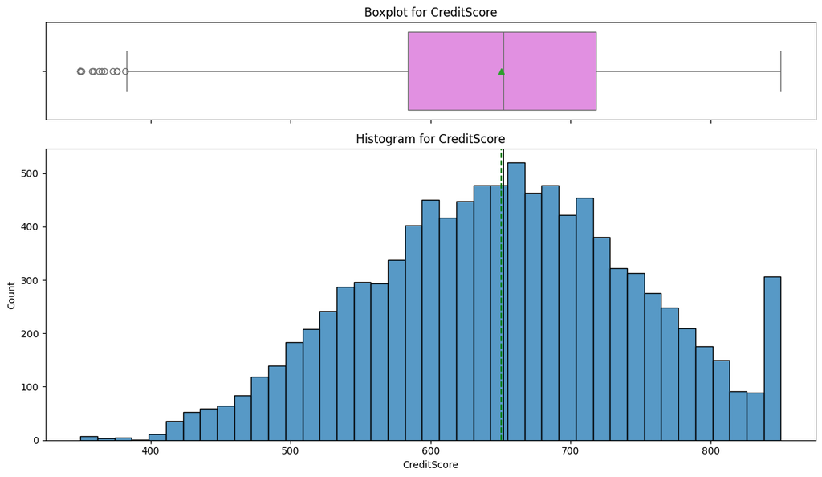

```python
# Histogram and boxplot for CreditScore
histogram_boxplot(data, "CreditScore")
```

#### **2. Age**

*Age of the customer*

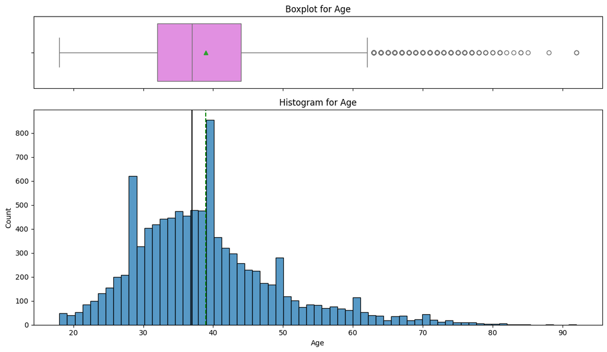

```python
# Histogram and boxplot for Age
histogram_boxplot(data, "Age")
```

#### **Observation**

- **Distribution**
  - Strong positive (right) skew in the age distribution
  - Unimodal with peak concentration around 37-40 years
  - Non-normal distribution with heavy right tail
  - Clear cutoff at 18 years (minimum age for banking)
- **Key Features**
  - Range: 18-92 years
  - Median (from boxplot): ~37 years
  - IQR (pink box): ~32-44 years (relatively narrow)
  - Mean (green triangle): ~39 years, slightly higher than median due to right skew
  - Substantial number of outliers above age 60 (dots in boxplot)
- **Key Observations**
  - Dominant young-to-middle-age customer base (30-45 years)
  - Sharp decline in customer numbers after age 45
  - Limited representation of customers above 60 years
  - Very few customers in 18-20 age range
  - Notable spikes at certain ages (e.g., around 40, 50, 60) suggesting possible age rounding in data collection

#### **3. Balance**

*Account balance*

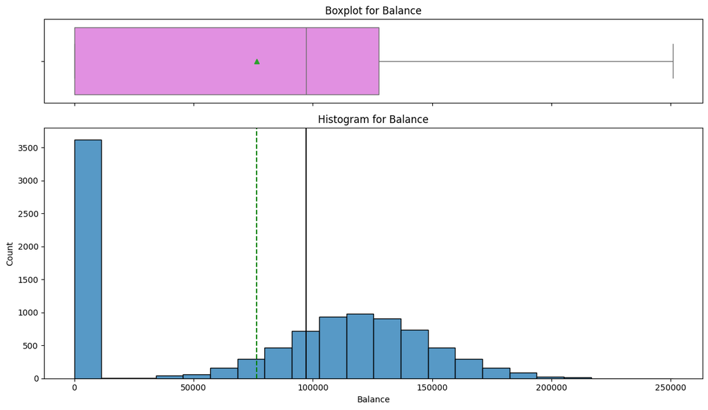

```python
# Histogram and boxplot for Balance
histogram_boxplot(data, "Balance")
```

#### **Observation**

This distribution will need careful handling in the model:

Need to use normalization techniques on this column. We will apply the technique on all numeric column.

#### **4. EstimatedSalary**

*Estimated salary*

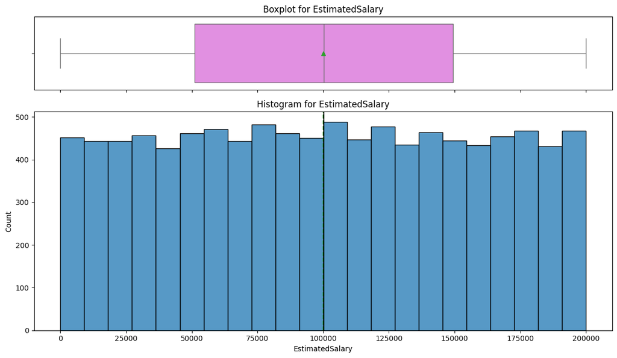

```python
# Histogram and boxplot for EstimatedSalary
histogram_boxplot(data, "EstimatedSalary")
```

#### **Observation**

- **Distribution**
  - Remarkably uniform/flat distribution
  - No significant skewness
  - Approximately uniform across the entire range
  - No obvious mode or central tendency
  - Almost rectangular in shape
- **Key Features**
  - Range: 11.58 to 199,992.48
  - Mean (green triangle): ~100,090
  - Median (vertical line): Almost identical to mean
  - IQR (pink box): Large and evenly distributed around median
  - No visible outliers in the boxplot
  - Consistent count (~400-500) in each salary bracket
- **Key Observations**
  - Equal representation across all salary ranges
  - No typical salary peaks or clusters
  - No income-based segmentation visible
  - Very few gaps or anomalies in the distribution
  - Each salary bracket has approximately the same number of customers

#### **5. Geography**

*A customer’s location*

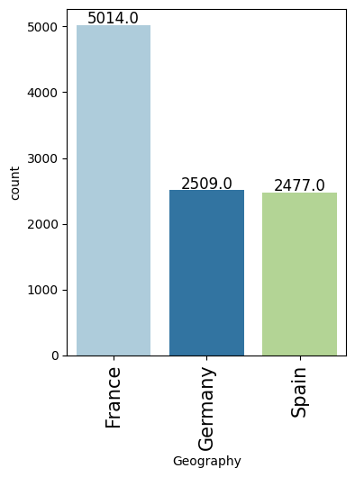

```python
# Labeled barplot for Geography
labeled_barplot(data, "Geography")
```

#### **Observation**

- **Distribution**
  - Non-uniform distribution across three countries
  - Germany and Spain have similar representation
- **Key Features**
  - France: 5,014 customers (50.14% of total)
  - Germany: 2,509 customers (25.09% of total)
  - Spain: 2,477 customers (24.77% of total)
  - Total customers: 10,000
  - Clear dominance of French market
- **Key Observations**
  - France has approximately twice as many customers as Germany or Spain
  - Very balanced distribution between Germany and Spain
  - Suggests primarily French-focused banking operations
  - Will need proper encoding.

#### **6. Gender**

*It defines the Gender of the customer*

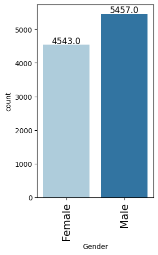

```python
# Labeled barplot for Gender
labeled_barplot(data, "Gender")
```

#### **Observation**

- **Distribution**
  - Binary distribution between Male and Female categories
  - Nearly balanced distribution with slight male majority
  - Simple categorical variable with two levels
  - No missing or other gender categories present
- **Key Features**
  - Male: 5,457 customers (54.57% of total)
  - Female: 4,543 customers (45.43% of total)
  - Total customers: 10,000
  - Difference of 914 customers between genders
  - Ratio approximately 55:45 (Male:Female)
- **Key Observations**
  - Relatively balanced gender distribution
  - Close enough to 50-50 to not require rebalancing
  - Will need encoding

#### **7. Tenure**

*Number of years for which the customer has been with the bank*

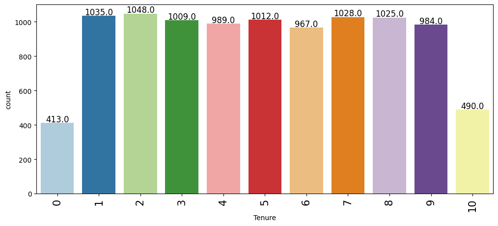

```python
# Labeled barplot for Tenure
labeled_barplot(data, "Tenure")
```

#### **Observation**

- **Distribution**
  - Discrete distribution from 0 to 10 years
  - Relatively uniform distribution except for extremes
  - Two notable exceptions:
    - Lower count at 0 years (new customers)
    - Lower count at 10 years (longest tenure)
  - Rest of the years show similar frequencies
- **Key Features**
  - Range: 0-10 years
  - Most common tenure: 1-2 years (~1035-1048 customers)
  - Least common: 0 years (413 customers) and 10 years (490 customers)
  - Middle years (3-9): Consistent around 1000 customers each
  - Total observations: 10,000 customers
- **Key Observations**
  - Bank has good customer retention (similar numbers across years 1-9)
  - Lower number of new customers (0 years)
  - There is a drop at 10 years.

#### **8. NumOfProducts**

*refers to the number of products that a customer has purchased through the bank.*

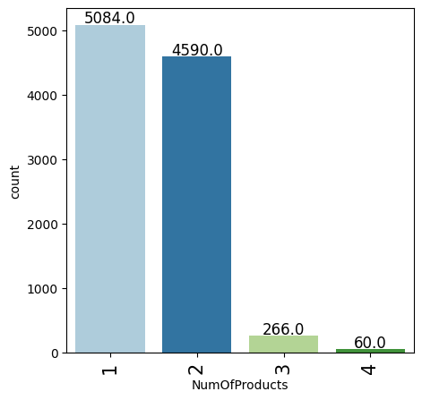

```python
# Labeled barplot for NumOfProducts
labeled_barplot(data, "NumOfProducts")
```

#### **Observation**

- ***Distribution**
  - Discrete values from 1 to 4 products
  - Strong concentration in lower product numbers (1-2)
  - Sharp decline for 3-4 products
  - Non-normal, non-uniform distribution
- **Key Features**
  - Range: 1-4 products
  - Most common: 1 product (5,084 customers, 50.84%)
  - Second most: 2 products (4,590 customers, 45.90%)
  - Very few with 3 products (266 customers, 2.66%)
  - Minimal with 4 products (60 customers, 0.60%)
- **Key Observations**
  - Over 96% of customers have 1-2 products
  - Extremely low adoption of 3-4 products

#### **9. HasCrCard**

*It is a categorical variable which decides whether the customer has credit card or not.*

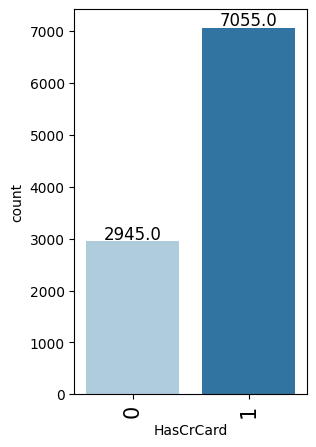

```python
# Labeled barplot for HasCrCard
labeled_barplot(data, "HasCrCard")
```

#### **Observation**

- **Distribution**
  - Binary distribution (0 or 1)
  - Unbalanced in favor of credit card holders
  - Simple categorical variable with two levels
- **Key Features**
  - Has Credit Card (1): 7,055 customers (70.55%)
  - No Credit Card (0): 2,945 customers (29.45%)
  - Total customers: 10,000
  - Ratio approximately 70:30 (Has:Doesn't Have)
- **Key Observations**
  - Strong credit card penetration in customer base
  - About 2.4 times more customers with credit cards than without

#### **10. IsActiveMember**

*Is is a categorical variable which decides whether the customer is active member of the bank or not ( Active member in the sense, using bank products regularly, making transactions etc )*

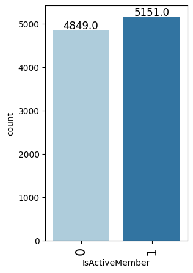

```python
# Labeled barplot for IsActiveMember
labeled_barplot(data, "IsActiveMember")
```

#### **Observation**

- **Distribution**
  - Binary distribution (0 or 1)
  - Nearly balanced between active and inactive members
  - Simple categorical variable with two levels
- **Key Features**
  - Active Members (1): 5,151 customers (51.51%)
  - Inactive Members (0): 4,849 customers (48.49%)
  - Total customers: 10,000
  - Ratio approximately 52:48 (Active:Inactive)
- ***Key Observations**
  - Almost perfect balance between active and inactive members
  - Only 302 more active members than inactive

#### **11. Exited**

*whether or not the customer left the bank within six month.*

It can take two values

- 0 = No ( Customer did not leave the bank )
- 1 = Yes ( Customer left the bank )

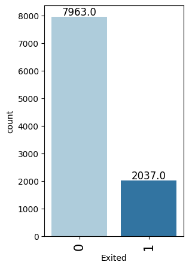

```python
# Labeled barplot for Exited
labeled_barplot(data, "Exited")
```

#### **Observation**

- **Distribution**
  - Binary distribution (0 or 1)
  - Highly imbalanced towards non-churned customers
  - Target variable for our classification problem
  - Clear majority/minority class split
- **Key Features**
  - Customer did not leave the bank (0): 7,963 customers (79.63%)
  - Customer left the bank (1): 2,037 customers (20.37%)
  - Total customers: 10,000
  - Ratio approximately 80:20 (Stayed:Left)
  - Significant class imbalance
- **Key Observations**
  - Class imbalance will need special handling:
    - SMOTE oversampling techniques

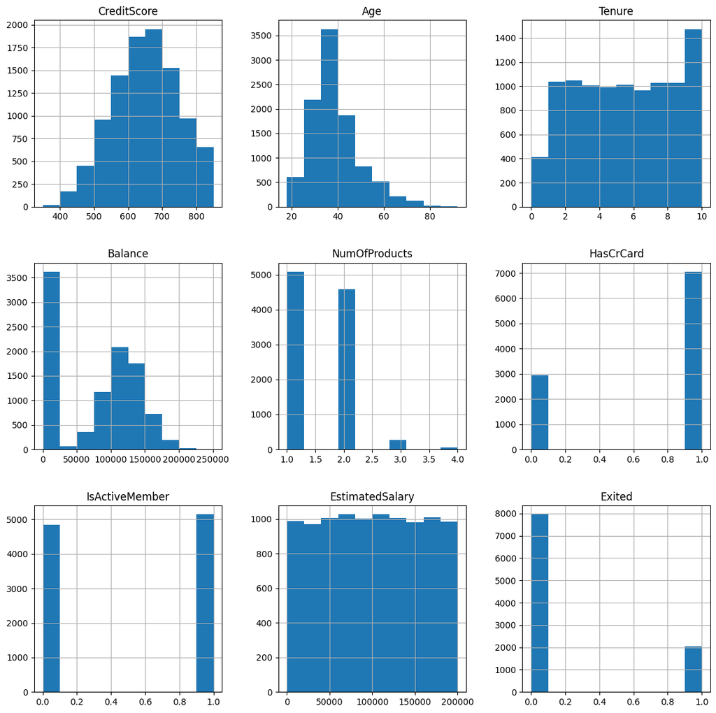

```python
# creating histograms
data.hist(figsize=(14, 14))
plt.show()
```

### Bivariate Analysis

#### **Correlation of Data (Heat Map)**

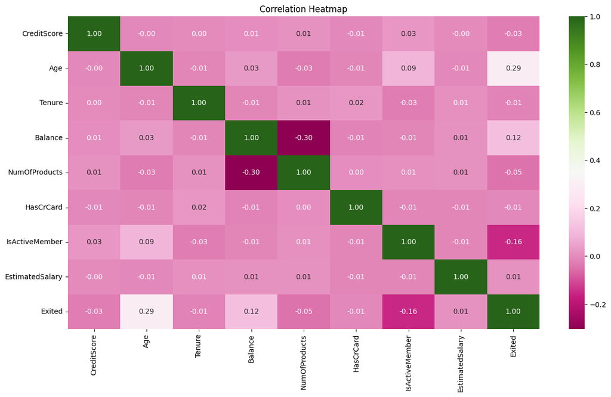

```python
# Correlation heatmap
# Select only numeric columns
numeric_columns = data.select_dtypes(include=['float64', 'int64']).columns

plt.figure(figsize=(15, 8))
plt.title("Correlation Heatmap")
sns.heatmap(data[numeric_columns].corr(), annot=True, cmap="PiYG", fmt='.2f')
plt.show()
```

#### **Observation**

- **Key Correlations with Exited (Churn)**
  - Age: Strongest positive correlation (0.29)
  - IsActiveMember: Notable negative correlation (-0.16)
  - Balance: Weak positive correlation (0.12)
  - NumOfProducts: Weak negative correlation (-0.05)
  - Other features show very weak correlations (< |0.05|)
- **Notable Feature Interactions**
  - Balance & NumOfProducts: Moderate negative correlation (-0.30)
    - Suggests customers with more products tend to have lower balances
  - Most other feature pairs show very weak correlations (< |0.10|)
  - Almost no correlation between most demographic and behavioral variables
- **Key Observations**
  - Overall weak to moderate correlations throughout
  - Age is the strongest predictor of churn
  - Active membership status is a protective factor against churn
  - Many features show independence from each other
  - Multicollinearity is not a major concern as correlations are generally low

#### **Let's check how a customer's "Exited" (Churn) varies with respect to other variables**

#### **Exited Vs Credit Score**

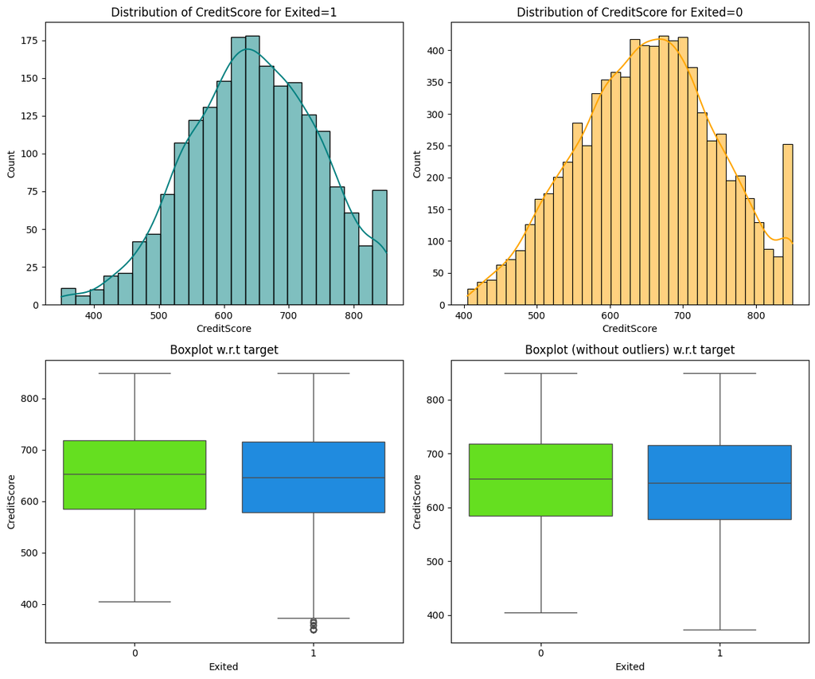

```python
# Lets analyse continuous variables
# Exited Vs CreditScore
distribution_plot_wrt_target(data, "CreditScore", "Exited")
```

#### **Exited Vs Age**

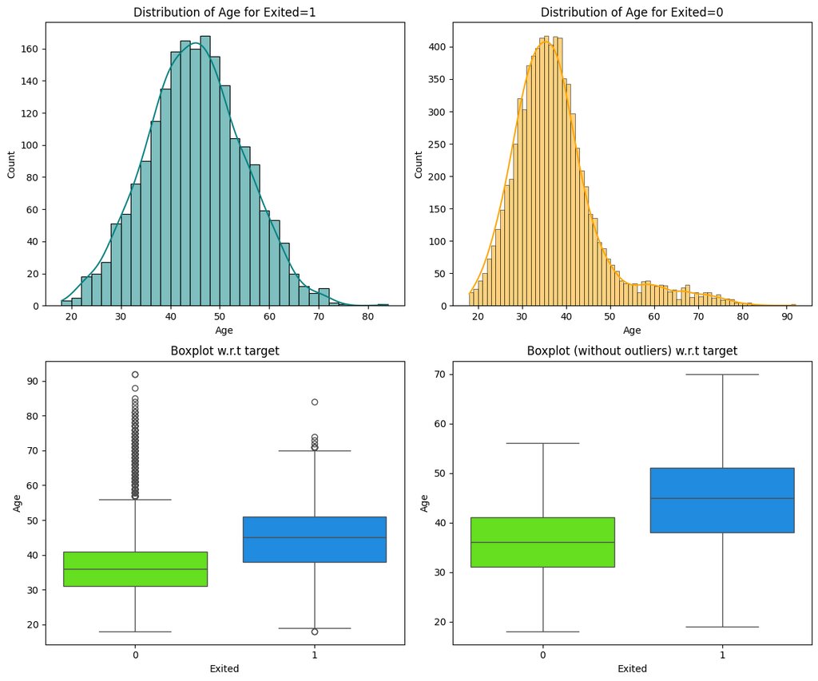

```python
# Lets analyse continuous variables
# Exited Vs Age
distribution_plot_wrt_target(data, "Age", "Exited")
```

#### **Exited Vs Tenure**

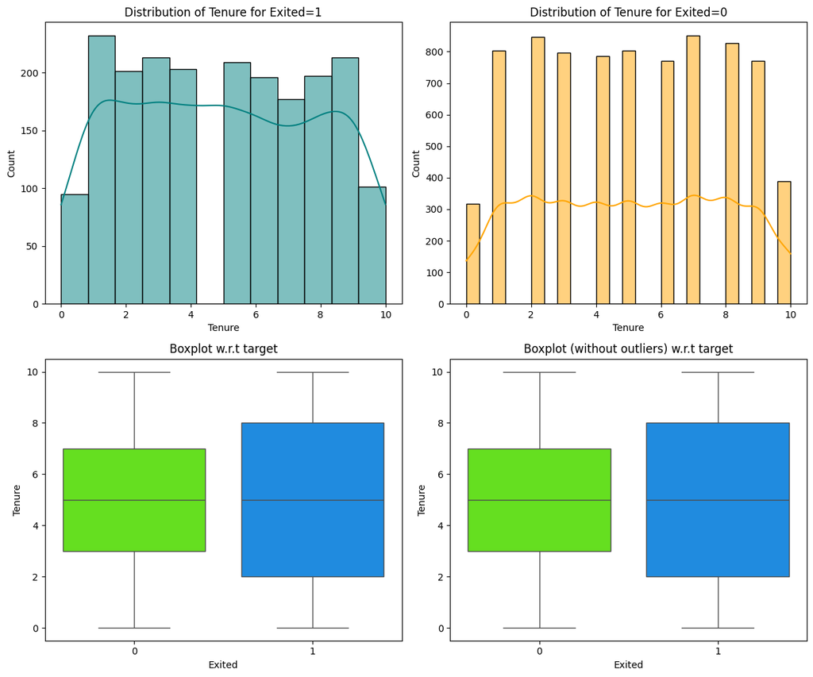

```python
# Lets analyse continuous variables
# Exited Vs Tenure
distribution_plot_wrt_target(data, "Tenure", "Exited")
```

#### **Exited Vs Balance**

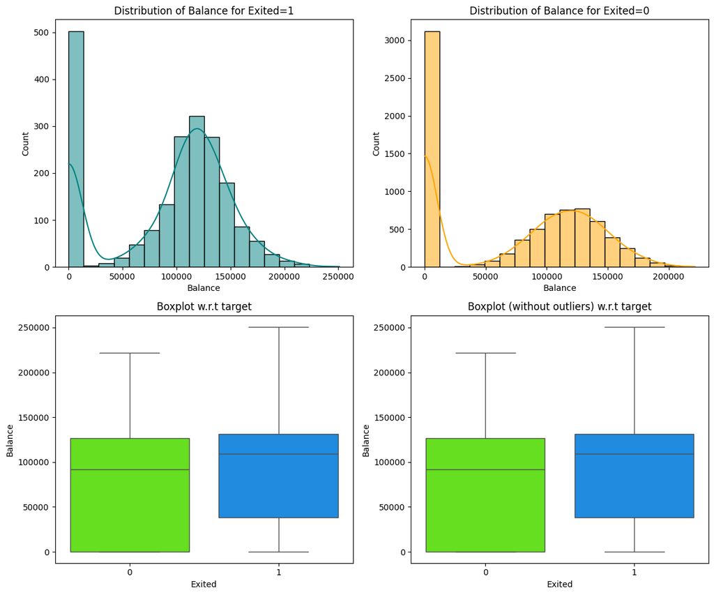

```python
# Lets analyse continuous variables
# Exited Vs Balance
distribution_plot_wrt_target(data, "Balance", "Exited")
```

#### **Exited Vs Estimated Salary**

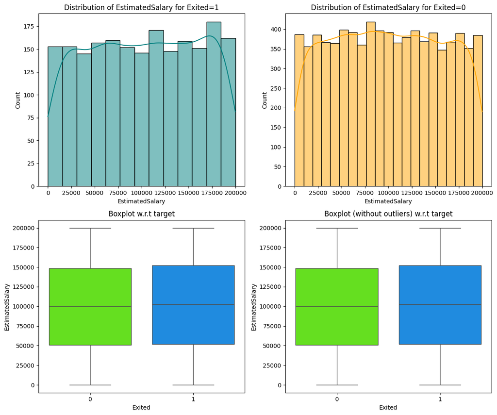

```python
# Lets analyse continuous variables
# Exited Vs EstimatedSalary
distribution_plot_wrt_target(data, "EstimatedSalary", "Exited")
```

#### **Observation**

- **Distribution Comparison**
  - Churned Customers (Exited=1)
    - Remarkably uniform distribution
    - Consistent counts across all salary ranges
    - Slight variations but no clear pattern
    - Each bin has approximately 150-175 customers
  - Non-Churned Customers (Exited=0)
    - Similarly uniform distribution
    - Higher counts due to class imbalance
    - Each bin has approximately 350-400 customers
    - Slight peak around 100,000-125,000
- **Key Features from Boxplots**
  - Median Salary
    - Churned: ~100,000
    - Non-Churned: ~100,000
  - Spread
    - Nearly identical IQR for both groups
    - Similar range (0-200,000)
    - No significant difference with/without outliers
    - Very similar distributions overall
- **Key Observations**
  - EstimatedSalary appears to be a weak predictor of churn
  - Notable similarities between groups
    - Almost identical distributions
    - Same median values
    - Similar spread and range
    - Uniform distribution across salary ranges
  - The uniformity suggests
    - Possibly synthetic or binned data
    - No salary-based targeting by the bank
    - Churn risk independent of salary level

#### **Exited Vs Geography**

```
Exited        0     1    All
Geography
All        7963  2037  10000
Germany    1695   814   2509
France     4204   810   5014
Spain      2064   413   2477
------------------------------------------------------------------------------------------------------------------------
```

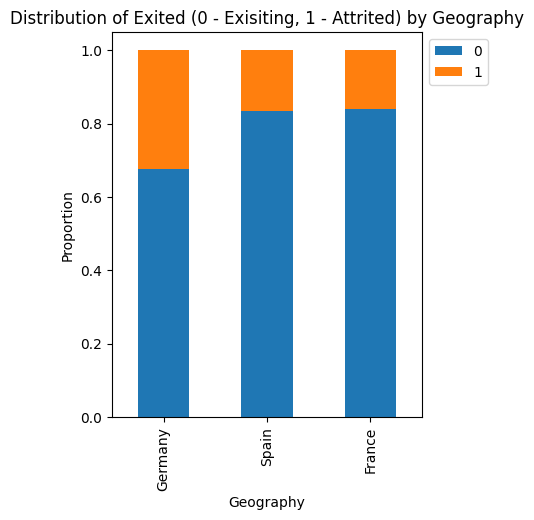

```python
# Lets do a stacked_barplot for columns with few unique values
# Exited Vs Geography
stacked_barplot(data, "Geography", "Exited")
```

#### **Exited Vs Gender**

```
Exited     0     1    All
Gender
All     7963  2037  10000
Female  3404  1139   4543
Male    4559   898   5457
------------------------------------------------------------------------------------------------------------------------
```

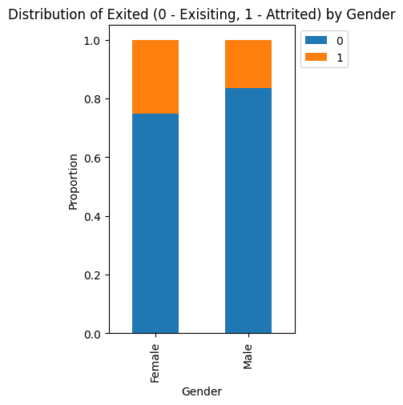

```python
# Lets do a stacked_barplot for columns with few unique values
# Exited Vs Gender
stacked_barplot(data, "Gender", "Exited")
```

#### **Observation**

- **Distribution by Gender**
  - Female
    - Total: 4543 customers
    - Churned: 1139 (25.1%)
    - Non-churned: 3404 (74.9%)
    - Higher churn rate than males
  - Male
    - Total: 5457 customers
    - Churned: 898 (16.5%)
    - Non-churned: 4559 (83.5%)
    - Lower churn rate
- **Key Features**
  - Overall gender balance
    - Males: 54.57% of customer base
    - Females: 45.43% of customer base
    - Relatively balanced customer base
  - Churn Patterns
    - Females have ~8.6% higher churn rate than males
    - Female churn rate is about 1.5 times male churn rate
    - More females churn despite smaller customer base
- **Key Observations**
  - Clear gender disparity in churn behavior
  - Female customers show significantly higher churn risk

Gender will be an important feature in our churn prediction model, particularly for identifying higher-risk female customers.

#### **Exited Vs Has Credit Card**

```
Exited        0     1    All
HasCrCard
All        7963  2037  10000
1          5631  1424   7055
0          2332   613   2945
------------------------------------------------------------------------------------------------------------------------
```

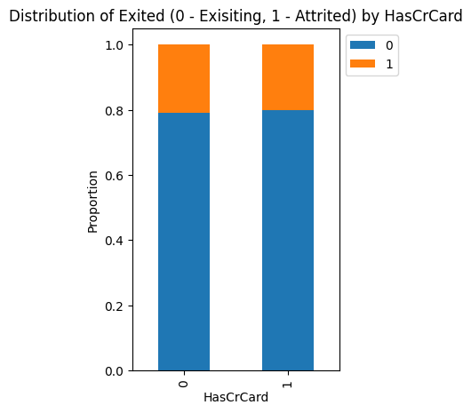

```python
# Lets do a stacked_barplot for columns with few unique values
# Exited Vs HasCrCard
stacked_barplot(data, "HasCrCard", "Exited")
```

#### **Observation**

- **Distribution by Credit Card Status**
  - With Credit Card (1)
    - Total: 7055 customers
    - Churned: 1424 (20.2%)
    - Non-churned: 5631 (79.8%)
  - Without Credit Card (0)
    - Total: 2945 customers
    - Churned: 613 (20.8%)
    - Non-churned: 2332 (79.2%)
- **Key Features**
  - Overall credit card penetration
    - With card: 70.55% of customers
    - Without card: 29.45% of customers
    - Strong credit card adoption
  - Churn Patterns:
    - Very similar churn rates between groups
    - Only 0.6% difference in churn rates
    - Credit card ownership doesn't appear to influence churn
- **Key Observations**
  - Credit card ownership has minimal impact on churn
  - Nearly identical churn proportions regardless of card status

#### **Exited Vs Is Active Member**

```
Exited             0     1    All
IsActiveMember
All             7963  2037  10000
0               3547  1302   4849
1               4416   735   5151
------------------------------------------------------------------------------------------------------------------------
```

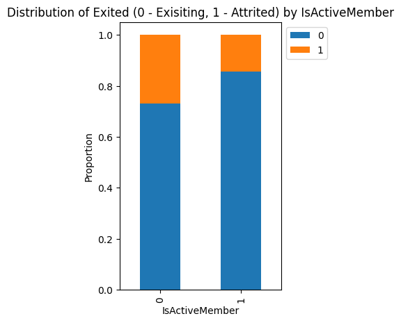

```python
# Lets do a stacked_barplot for columns with few unique values
# Exited Vs IsActiveMember
stacked_barplot(data, "IsActiveMember", "Exited")
```

#### **Observation**

- **Distribution by Activity Status**
  - Active Members (1)
    - Total: 5151 customers
    - Churned: 735 (14.3%)
    - Non-churned: 4416 (85.7%)
    - Lower churn rate
  - Inactive Members (0)
    - Total: 4849 customers
    - Churned: 1302 (26.9%)
    - Non-churned: 3547 (73.1%)
    - Higher churn rate
- **Key Features**
  - Overall activity status
    - Active: 51.51% of customers
    - Inactive: 48.49% of customers
    - Nearly balanced split
  - Churn Patterns
    - Inactive members have 12.6% higher churn rate
    - Inactive members almost 2x more likely to churn
    - Active membership appears protective against churn
- **Key Observations**
  - Strong relationship between activity status and churn

IsActiveMember will be an important feature in our churn prediction model, with inactive status being a significant risk factor for churn.

#### **Exited Vs Number of Products**

```
Exited            0     1    All
NumOfProducts
All            7963  2037  10000
1              3675  1409   5084
2              4242   348   4590
3                46   220    266
4                 0    60     60
------------------------------------------------------------------------------------------------------------------------
```

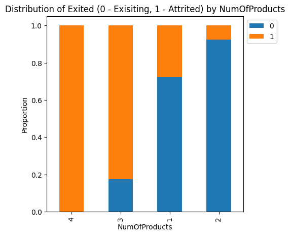

```python
# Lets do a stacked_barplot for columns with few unique values
# Exited Vs NumOfProducts
stacked_barplot(data, "NumOfProducts", "Exited")
```

#### **Observation**

- **Distribution by Number of Products**
  - One Product
    - Total: 5084 customers
    - Churned: 1409 (27.7%)
    - Non-churned: 3675 (72.3%)
  - Two Products
    - Total: 4590 customers
    - Churned: 348 (7.6%)
    - Non-churned: 4242 (92.4%)
  - Three Products
    - Total: 266 customers
    - Churned: 220 (82.7%)
    - Non-churned: 46 (17.3%)
  - Four Products:
    - Total: 60 customers
    - Churned: 60 (100%)
    - Non-churned: 0 (0%)
- **Key Features**
  - Product concentration
    - ~96% of customers have 1-2 products
    - Very few customers with 3-4 products
    - Sharp decline in customer numbers with more products
  - Churn Patterns
    - Dramatic variation in churn rates by product number
    - U-shaped relationship with number of products
    - 100% churn rate with four products
- **Key Observations**
  - Number of products strongly predicts churn
  - Optimal number appears to be two products
  - Very concerning patterns:
    - All customers with 4 products churned
    - Very high churn rate (82.7%) with 3 products
    - Single-product customers have moderate churn risk

NumOfProducts will be a crucial predictor in our churn model, with a clear non-linear relationship to churn risk.

## Data Preprocessing

### **Outlier Detection**

```python
# Select only numeric columns
numeric_cols = data.select_dtypes(include=['float64', 'int64']).columns
numeric_data = data[numeric_cols]

# Now calculate quantiles
Q1 = numeric_data.quantile(0.25)  # To find the 25th percentile
Q3 = numeric_data.quantile(0.75)  # To find the 75th percentile

IQR = Q3 - Q1  # Inter Quantile Range (75th percentile - 25th percentile)

# Calculate bounds for outliers
lower_bound = Q1 - 1.5 * IQR
upper_bound = Q3 + 1.5 * IQR
```

```python
# checking the % outliers
((data.select_dtypes(include=["float64", "int64"]) < lower_bound) | (data.select_dtypes(include=["float64", "int64"]) > upper_bound)).sum() / len(data) * 100
```

|  | 0 |
| --- | --- |
| CreditScore | 0.150 |
| Age | 3.590 |
| Tenure | 0.000 |
| Balance | 0.000 |
| NumOfProducts | 0.600 |
| HasCrCard | 0.000 |
| IsActiveMember | 0.000 |
| EstimatedSalary | 0.000 |
| Exited | 20.370 |

**dtype:** float64

#### **Observation**

- **Distribution of Outliers**
  - CreditScore: 0.15% of data points are outliers
  - Age: 3.59% of data points are outliers
  - Tenure: 0% outliers
  - Balance: 0% outliers
  - NumOfProducts: 0.6% outliers
  - HasCrCard: 0% outliers (binary variable)
  - IsActiveMember: 0% outliers (binary variable)
  - EstimatedSalary: 0% outliers
  - Exited: 20.37% (this is our target variable's class distribution, not outliers)
- **Key Features**
  - Most features show very few or no outliers
  - Age has the highest percentage of outliers (3.59%)
  - Binary variables naturally have no outliers
  - CreditScore has minimal outliers
- **Key Observations**
  - Overall clean dataset with few outliers

Though there are few outliers, we will not treat them as they are vital for our analysis.

### Train-validation-test Split

```python
#Take a copy of original data
ds_for_model = data.copy()
```

```python
# Print class distribution in each set
print("\nClass distribution in original data set:")
print(ds_for_model['Exited'].value_counts(normalize=True))
```

```
Class distribution in original data set:
Exited
0   0.796
1   0.204
Name: proportion, dtype: float64
```

### **Observation**

- Class 0 (Non-churned): 79.6% of customers
- Class 1 (Churned): 20.4% of customers
- Clear class imbalance with ratio approximately 80:20

```python
# Split feature and target variables
X = ds_for_model.drop("Exited", axis=1) # Dropping target variable
y = ds_for_model["Exited"]
```

```python
# Splitting data into training, validation and test dataset.
# First split: Sperate test set (20% of data)
X_train_val, X_test, y_train_val, y_test = train_test_split(X, y, test_size=0.2, random_state=1)

# Second split: Separate train and validation sets (validation is 25% of remaining 80% ≈ 20% of total)
X_train, X_val, y_train, y_val = train_test_split(X_train_val, y_train_val, test_size=0.25, random_state=1)

# Create distribution data with counts and percentages
def get_distribution(y):
    counts = y.value_counts()
    percentages = y.value_counts(normalize=True)
    combined = pd.DataFrame({
        'Count': counts,
        'Percentage': percentages * 100
    })
    return combined

# Create DataFrames for each set
original_dist = get_distribution(y)
train_dist = get_distribution(y_train)
val_dist = get_distribution(y_val)
test_dist = get_distribution(y_test)

# Add a 'Set' identifier to each DataFrame
original_dist['Set'] = 'Original Set'
train_dist['Set'] = 'Training Set'
val_dist['Set'] = 'Validation Set'
test_dist['Set'] = 'Test Set'

# Concatenate all DataFrames
dist_df = pd.concat([original_dist, train_dist, val_dist, test_dist])

# Reset index to make 'Exited' a column
dist_df = dist_df.reset_index()
dist_df = dist_df.rename(columns={'index': 'Exited'})  # Changed from 'Class' to 'Exited'

# Replace class values with descriptive labels
dist_df['Exited'] = dist_df['Exited'].map({0: 'Non-churned (0)', 1: 'Churned (1)'})

# Format percentages
dist_df['Percentage'] = dist_df['Percentage'].round(1).astype(str) + '%'

# Reorder columns for better presentation
dist_df = dist_df[['Set', 'Exited', 'Count', 'Percentage']]

print("\nDetailed Class Distribution Across Sets:")
print(dist_df.to_string(index=False))
```

```
Detailed Class Distribution Across Sets:
           Set          Exited  Count Percentage
  Original Set Non-churned (0)   7963      79.6%
  Original Set     Churned (1)   2037      20.4%
  Training Set Non-churned (0)   4793      79.9%
  Training Set     Churned (1)   1207      20.1%
Validation Set Non-churned (0)   1585      79.2%
Validation Set     Churned (1)    415      20.8%
      Test Set Non-churned (0)   1585      79.2%
      Test Set     Churned (1)    415      20.8%
```

#### **Observation**

**Detailed Class Distribution Across Sets:**

| Set | Exited | Count | Percentage |
| --- | --- | --- | --- |
| Original Set | Non-churned (0) | 7963 | 79.6% |
|  | Churned (1) | 2037 | 20.4% |
| Training Set. | Non-churned (0) | 4793 | 79.9% |
|  | Churned (1) | 1207 | 20.1% |
| Validation Set | Non-churned (0) | 1585 | 79.2% |
|  | Churned (1) | 415 | 20.8% |
| Test Set | Non-churned (0) | 1585 | 79.2% |
|  | Churned (1) | 415 | 20.8% |

**The distribution of class are simillar among all data sets.**

### Dummy Variable Creation

**Encoding categorical variables**

- Identify categorical columns in the dataset and convert them to category
- Benefits
  - Memory efficienty
  - Better performance
  - More appropriate representation of categorical data.

```python
# Create Dummy Variables
print("Categorical values: ",X.select_dtypes(include=["object", "category"]))
print("-" * 30)
print("Shape of dataset before encoding.")
print("-" * 30)
print(f"Train dataset: {X_train.shape}\nValidation dataset: {X_val.shape}\nTest dataset: {X_test.shape}")
print("=" * 30)

# Train dataset
# Create dummies and drop one of it
X_train = pd.get_dummies(X_train, drop_first=True)
X_train = X_train.astype(float)

# Validation dataset
# Create dummies and drop one of it
X_val = pd.get_dummies(X_val, drop_first=True)
X_val = X_val.astype(float)

# Test dataset
# Create dummies and drop one of it
X_test = pd.get_dummies(X_test, drop_first=True)
X_test = X_test.astype(float)

print("Shape of dataset after encoding.")
print("-" * 30)
print(f"Train dataset: {X_train.shape}\nValidation dataset: {X_val.shape}\nTest dataset: {X_test.shape}")
print("=" * 30)
```

```
Categorical values:       Geography  Gender
0       France  Female
1        Spain  Female
2       France  Female
3       France  Female
4        Spain  Female
...        ...     ...
9995    France    Male
9996    France    Male
9997    France  Female
9998   Germany    Male
9999    France  Female

[10000 rows x 2 columns]
------------------------------
Shape of dataset before encoding.
------------------------------
Train dataset: (6000, 10)
Validation dataset: (2000, 10)
Test dataset: (2000, 10)
==============================
Shape of dataset after encoding.
------------------------------
Train dataset: (6000, 11)
Validation dataset: (2000, 11)
Test dataset: (2000, 11)
==============================
```

**Observation**

- Shape of dataset before encoding.
  - Train dataset: (6000, 10)
  - Validation dataset: (2000, 10)
  - Test dataset: (2000, 10)
- Shape of dataset after encoding.
  - Train dataset: (6000, 11)
  - Validation dataset: (2000, 11)
  - Test dataset: (2000, 11)

**After creating dummies for categorical variables, there are 11 columns**

```python
# check the top 5 rows from the train dataset after creating dummies
X_train.head()
```

|  | CreditScore | Age | Tenure | Balance | NumOfProducts | HasCrCard | IsActiveMember | EstimatedSalary | Geography_Germany | Geography_Spain | Gender_Male |
| --- | --- | --- | --- | --- | --- | --- | --- | --- | --- | --- | --- |
| 4495 | 789.000 | 32.000 | 7.000 | 69423.520 | 1.000 | 1.000 | 0.000 | 107499.390 | 0.000 | 0.000 | 0.000 |
| 6470 | 583.000 | 41.000 | 5.000 | 77647.600 | 1.000 | 1.000 | 0.000 | 190429.520 | 1.000 | 0.000 | 0.000 |
| 2221 | 767.000 | 35.000 | 6.000 | 132253.220 | 1.000 | 1.000 | 0.000 | 115566.570 | 1.000 | 0.000 | 0.000 |
| 7686 | 718.000 | 48.000 | 9.000 | 0.000 | 2.000 | 1.000 | 1.000 | 72105.630 | 0.000 | 0.000 | 1.000 |
| 9419 | 686.000 | 26.000 | 1.000 | 57422.620 | 1.000 | 1.000 | 1.000 | 79189.400 | 1.000 | 0.000 | 1.000 |

### Data Normalization

**Why data normalization is important, especially for neural networks:**

- Brings all features to similar scale
- Prevents features with larger values from dominating
- Helps gradient descent converge faster
- Reduces the chance of getting stuck in local optima
- Makes model training more stable

**In Our Dataset:**

- Balance: 0 to 250,000
- Age: 18 to 92
- CreditScore: 350 to 850
- EstimatedSalary: 11 to 199,992

**Without normalization, Balance would have much more influence than Age simply due to its scale**

```python
# Initialize the scaler
scaler = StandardScaler()

# Select only numeric columns for scaling
numeric_columns = ['CreditScore', 'Age', 'Tenure', 'Balance', 'EstimatedSalary']

# StandardScaler transforms features to mean=0 and std=1
# Fit scaler on training data only (to prevent data leakage)
X_train[numeric_columns] = scaler.fit_transform(X_train[numeric_columns])

# Apply same transformation to validation and test sets
# Using parameters learned from training data
X_val[numeric_columns] = scaler.transform(X_val[numeric_columns])
X_test[numeric_columns] = scaler.transform(X_test[numeric_columns])

# Quick check
print("\nMean of scaled features (should be close to 0):")
print(X_train[numeric_columns].mean())
print("\nStd of scaled features (should be close to 1):")
print(X_train[numeric_columns].std())
```

```
Mean of scaled features (should be close to 0):
CreditScore        0.000
Age               -0.000
Tenure            -0.000
Balance            0.000
EstimatedSalary   -0.000
dtype: float64

Std of scaled features (should be close to 1):
CreditScore       1.000
Age               1.000
Tenure            1.000
Balance           1.000
EstimatedSalary   1.000
dtype: float64
```

## Model Building

#### **Utility Functions**

```python
def plot(history, name):
    """
    Function to plot loss/accuracy

    history: an object which stores the metrics and losses.
    name: can be one of Loss or Recall
    """
    fig, ax = plt.subplots() #Creating a subplot with figure and axes.
    plt.plot(history.history[name]) #Plotting the train accuracy or train loss
    plt.plot(history.history['val_'+name]) #Plotting the validation accuracy or validation loss

    plt.title('Model ' + name.capitalize()) #Defining the title of the plot.
    plt.ylabel(name.capitalize()) #Capitalizing the first letter.
    plt.xlabel('Epoch') #Defining the label for the x-axis.
    fig.legend(['Train', 'Validation'], loc="outside right upper") #Defining the legend, loc controls the position of the legend.
```

```python
def plot_roc_and_find_optimal_threshold(model, X, y, model_name='Model'):
    """
    Plot ROC curve and find optimal threshold using G-mean

    Parameters:
    model: trained model object
    X: feature matrix
    y: true labels
    model_name: name of the model for plot title (default='Model')

    Returns:
    optimal_threshold: threshold that maximizes G-mean
    g_mean: maximum G-mean value
    """

    # Predicting probabilities
    y_pred_proba = model.predict(X)
    # Keeping probabilities for positive outcomes
    y_pred_proba = y_pred_proba[:, 0]

    # Calculating ROC curve
    fpr, tpr, thresholds = roc_curve(y, y_pred_proba)

    # Calculating G-mean for each threshold
    gmeans = np.sqrt(tpr * (1-fpr))

    # Finding optimal threshold
    ix = np.argmax(gmeans)
    optimal_threshold = thresholds[ix]
    g_mean = gmeans[ix]

    # Creating plot
    plt.figure(figsize=(8, 6))
    plt.plot([0,1], [0,1], linestyle='--', label='No Skill')
    plt.plot(fpr, tpr, marker='.', label='ROC curve')
    plt.scatter(fpr[ix], tpr[ix], marker='o', color='black', label=f'Best Threshold={optimal_threshold:.3f}')

    # Customizing plot
    plt.xlabel('False Positive Rate')
    plt.ylabel('True Positive Rate')
    plt.title(f'ROC Curve - {model_name}')
    plt.legend()
    plt.grid(True)

    # Print optimal values
    print(f'Best Threshold={optimal_threshold:.3f}, G-Mean={g_mean:.3f}')

    plt.show()

    return optimal_threshold, g_mean
```

```python
def make_confusion_matrix(actual_targets, predicted_targets, perf_metric):
    """
    To plot the confusion_matrix with percentages

    actual_targets: actual target (dependent) variable values
    predicted_targets: predicted target (dependent) variable values
    perf_metric: Has Accuracy, Precision, Recall, F1 Score
    """
    cm = confusion_matrix(actual_targets, predicted_targets)
    categories = ['Non-churned', 'Churned']
    cmap = sns.cm.rocket_r

    labels = np.asarray(
        [
            ["{0:0.0f}".format(item) + "\n{0:.2%}".format(item / cm.flatten().sum())]
            for item in cm.flatten()
        ]
    ).reshape(cm.shape[0], cm.shape[1])

    plt.figure(figsize=(7, 5))

    sns.heatmap(cm, annot=labels, fmt="", cmap=cmap, xticklabels=categories, yticklabels=categories)

    plt.ylabel("True label")
    plt.xlabel("Predicted label")

    plt.show()
    print(perf_metric.to_string(index=False))
```

```python
# defining a function to compute different metrics to check performance of a classification model built using statsmodels
def model_performance_classification(
    model, predictors, target, threshold=0.5
):
    """
    Function to compute different metrics to check classification model performance

    model: classifier
    predictors: independent variables
    target: dependent variable
    threshold: threshold for classifying the observation as class 1
    """

    # checking which probabilities are greater than threshold
    pred = model.predict(predictors) > threshold

    acc = accuracy_score(target, pred)  # to compute Accuracy
    recall = recall_score(target, pred, average='weighted')  # to compute Recall
    precision = precision_score(target, pred, average='weighted')  # to compute Precision
    f1 = f1_score(target, pred, average='weighted')  # to compute F1-score

    # creating a dataframe of metrics
    df_perf = pd.DataFrame(
        {"Accuracy": acc, "Recall": recall, "Precision": precision, "F1 Score": f1,},
        index=[0],
    )

    return df_perf, pred
```

### Model Evaluation Criterion

- **Correct Predition:**
  - True positives (TP) are failures correctly predicted by the model.
- **Types of Wrong Predictions:**
  - **False Positive (FP):** Predicting a customer will churn when they actually won't
    - Business Impact: Unnecessary retention efforts and resources
    - Cost: Additional marketing/retention costs
  - **False Negative (FN):** Predicting a customer won't churn when they actually will
    - Business Impact: Loss of customer without preventive action
    - Cost: Lost revenue, customer acquisition costs, reputation damage
- **More Critical Case - False Negatives are more costly because:**
  - Losing a customer is more expensive than spending on retention
  - Customer acquisition costs are typically higher than retention costs
  - Lost revenue from customer's lifetime value
  - Harder to win back a churned customer
- **Why Recall is Important:** Recall (Sensitivity) is indeed crucial because:
  - Recall = TP/(TP + FN)
  - Measures our ability to catch actual churners
  - Higher recall means fewer missed churners
  - Directly addresses the costlier error type
- **Recommended Metrics:**
  - Recall: To minimize missed churners
  - ROC-AUC: Overall model discrimination
  - F1-Score: Harmonic mean of precision and recall
  - Confusion Matrix: Detailed error analysis

```python
# defining the batch size and # epochs upfront as we'll be using the same values for all models
# After experimenting with different epochs and batch_size settled on this
epochs = 80
batch_size = 48
```

### Neural Network with SGD Optimizer

**Model 0**

| Model | Model 0 - SGD Optimizer |
| --- | --- |
| **Layers** | 3 with 66, 33 and 1 neurons respectively |
| **Activation function for Hidden layer** | ReLU |
| **Activation for output layer** | Sigmoid |
| **Optimizer** | SGD |
| **Learning rate** | 0.001 |
| **Loss function** | binary_crossentropy |
| **Metrics** | Accuracy, Recall |
| **Epochs** | 80 |
| **Batch Size** | 48 |

```python
# clears the current Keras session, resetting all layers and models previously created, freeing up memory and resources.
backend.clear_session()
#Fixing the seed for random number generators so that we can ensure we receive the same output everytime
np.random.seed(28)
random.seed(28)
tf.random.set_seed(28)
```

```python
# Initialize the Sequential Neural Network
model_0 = Sequential()

# model_0.add(Dense(22, input_dim=X_train.shape[1], activation='relu'))
# model_0.add(Dense(11, activation='relu'))
# model_0.add(Dense(1, activation='sigmoid'))


# model_0.add(Dense(33, input_dim=X_train.shape[1], activation='relu'))
# model_0.add(Dense(16, activation='relu'))
# model_0.add(Dense(1, activation='sigmoid'))

# Adding input layer with 66 nodes
# input_dim automatically determined from training data shape
model_0.add(Dense(66, input_dim=X_train.shape[1], activation='relu'))

# Adding hidden layer with 48 nodes (half of previous layer)
# ReLU activation for non-linear transformation
model_0.add(Dense(33, activation='relu'))

# Adding output layer with 1 node for binary classification
# Sigmoid activation to get probability between 0 and 1
model_0.add(Dense(1, activation='sigmoid'))
```

```python
model_0.summary()
```

```
Model: "sequential"
```

```
┏━━━━━━━━━━━━━━━━━━━━━━━━━━━━━━━━━━━━━━┳━━━━━━━━━━━━━━━━━━━━━━━━━━━━━┳━━━━━━━━━━━━━━━━━┓
┃ Layer (type)                         ┃ Output Shape                ┃         Param # ┃
┡━━━━━━━━━━━━━━━━━━━━━━━━━━━━━━━━━━━━━━╇━━━━━━━━━━━━━━━━━━━━━━━━━━━━━╇━━━━━━━━━━━━━━━━━┩
│ dense (Dense)                        │ (None, 66)                  │             792 │
├──────────────────────────────────────┼─────────────────────────────┼─────────────────┤
│ dense_1 (Dense)                      │ (None, 33)                  │           2,211 │
├──────────────────────────────────────┼─────────────────────────────┼─────────────────┤
│ dense_2 (Dense)                      │ (None, 1)                   │              34 │
└──────────────────────────────────────┴─────────────────────────────┴─────────────────┘
```

```
 Total params: 3,037 (11.86 KB)
```

```
 Trainable params: 3,037 (11.86 KB)
```

```
 Non-trainable params: 0 (0.00 B)
```

```python
# Compiling with SGD optimizer and binary cross entropy loss function.
#optimizer = tf.keras.optimizers.SGD(learning_rate=0.01)

# The above learning rate recall was not good
optimizer = tf.keras.optimizers.SGD(learning_rate=0.001)
model_0.compile(optimizer=optimizer,
              loss='binary_crossentropy',
              metrics=['accuracy', tf.keras.metrics.Recall()])
```

```python
# Fitting/Training the Neural Network
# Trying out different batch_size and epoxhs
# epochs = 50
# batch_size = 32
# epochs = 200
# batch_size = 32


# Train the Neural Network on training data
start = time.time()
history_0 = model_0.fit(
    X_train, y_train,
    batch_size=batch_size,
    validation_data=(X_val, y_val),  # Using validation set to monitor overfitting
    epochs=epochs,  # Training iterations
    verbose=1    # Show training progress
)

end = time.time()
print(f"Time taken: {end - start} seconds")
```

```
125/125 ━━━━━━━━━━━━━━━━━━━━ 3s 10ms/step - accuracy: 0.5877 - loss: 0.6839 - recall: 0.4485 - val_accuracy: 0.7180 - val_loss: 0.6423 - val_recall: 0.1325
125/125 ━━━━━━━━━━━━━━━━━━━━ 0s 4ms/step - accuracy: 0.7496 - loss: 0.6256 - recall: 0.1147 - val_accuracy: 0.7815 - val_loss: 0.6010 - val_recall: 0.0169
125/125 ━━━━━━━━━━━━━━━━━━━━ 1s 4ms/step - accuracy: 0.8001 - loss: 0.5852 - recall: 0.0140 - val_accuracy: 0.7930 - val_loss: 0.5724 - val_recall: 0.0048
125/125 ━━━━━━━━━━━━━━━━━━━━ 0s 3ms/step - accuracy: 0.8057 - loss: 0.5567 - recall: 0.0015 - val_accuracy: 0.7920 - val_loss: 0.5524 - val_recall: 0.0000e+00
125/125 ━━━━━━━━━━━━━━━━━━━━ 1s 3ms/step - accuracy: 0.8060 - loss: 0.5364 - recall: 0.0000e+00 - val_accuracy: 0.7925 - val_loss: 0.5382 - val_recall: 0.0000e+00
125/125 ━━━━━━━━━━━━━━━━━━━━ 1s 4ms/step - accuracy: 0.8060 - loss: 0.5216 - recall: 0.0000e+00 - val_accuracy: 0.7925 - val_loss: 0.5280 - val_recall: 0.0000e+00
125/125 ━━━━━━━━━━━━━━━━━━━━ 1s 4ms/step - accuracy: 0.8060 - loss: 0.5106 - recall: 0.0000e+00 - val_accuracy: 0.7925 - val_loss: 0.5204 - val_recall: 0.0000e+00
125/125 ━━━━━━━━━━━━━━━━━━━━ 1s 3ms/step - accuracy: 0.8060 - loss: 0.5024 - recall: 0.0000e+00 - val_accuracy: 0.7925 - val_loss: 0.5147 - val_recall: 0.0000e+00
125/125 ━━━━━━━━━━━━━━━━━━━━ 1s 3ms/step - accuracy: 0.8060 - loss: 0.4960 - recall: 0.0000e+00 - val_accuracy: 0.7925 - val_loss: 0.5102 - val_recall: 0.0000e+00
125/125 ━━━━━━━━━━━━━━━━━━━━ 1s 3ms/step - accuracy: 0.8060 - loss: 0.4909 - recall: 0.0000e+00 - val_accuracy: 0.7925 - val_loss: 0.5066 - val_recall: 0.0000e+00
125/125 ━━━━━━━━━━━━━━━━━━━━ 0s 3ms/step - accuracy: 0.8060 - loss: 0.4868 - recall: 0.0000e+00 - val_accuracy: 0.7925 - val_loss: 0.5035 - val_recall: 0.0000e+00
125/125 ━━━━━━━━━━━━━━━━━━━━ 1s 3ms/step - accuracy: 0.8060 - loss: 0.4832 - recall: 0.0000e+00 - val_accuracy: 0.7925 - val_loss: 0.5008 - val_recall: 0.0000e+00
125/125 ━━━━━━━━━━━━━━━━━━━━ 0s 4ms/step - accuracy: 0.8060 - loss: 0.4801 - recall: 0.0000e+00 - val_accuracy: 0.7925 - val_loss: 0.4984 - val_recall: 0.0000e+00
125/125 ━━━━━━━━━━━━━━━━━━━━ 0s 4ms/step - accuracy: 0.8060 - loss: 0.4774 - recall: 0.0000e+00 - val_accuracy: 0.7925 - val_loss: 0.4962 - val_recall: 0.0000e+00
125/125 ━━━━━━━━━━━━━━━━━━━━ 0s 3ms/step - accuracy: 0.8060 - loss: 0.4749 - recall: 0.0000e+00 - val_accuracy: 0.7925 - val_loss: 0.4941 - val_recall: 0.0000e+00
125/125 ━━━━━━━━━━━━━━━━━━━━ 0s 3ms/step - accuracy: 0.8060 - loss: 0.4727 - recall: 0.0000e+00 - val_accuracy: 0.7925 - val_loss: 0.4922 - val_recall: 0.0000e+00
125/125 ━━━━━━━━━━━━━━━━━━━━ 0s 4ms/step - accuracy: 0.8060 - loss: 0.4706 - recall: 0.0000e+00 - val_accuracy: 0.7925 - val_loss: 0.4903 - val_recall: 0.0000e+00
125/125 ━━━━━━━━━━━━━━━━━━━━ 1s 5ms/step - accuracy: 0.8060 - loss: 0.4686 - recall: 0.0000e+00 - val_accuracy: 0.7925 - val_loss: 0.4886 - val_recall: 0.0000e+00
125/125 ━━━━━━━━━━━━━━━━━━━━ 1s 6ms/step - accuracy: 0.8060 - loss: 0.4668 - recall: 0.0000e+00 - val_accuracy: 0.7925 - val_loss: 0.4869 - val_recall: 0.0000e+00
125/125 ━━━━━━━━━━━━━━━━━━━━ 1s 7ms/step - accuracy: 0.8060 - loss: 0.4650 - recall: 0.0000e+00 - val_accuracy: 0.7925 - val_loss: 0.4853 - val_recall: 0.0000e+00
125/125 ━━━━━━━━━━━━━━━━━━━━ 1s 7ms/step - accuracy: 0.8060 - loss: 0.4633 - recall: 0.0000e+00 - val_accuracy: 0.7925 - val_loss: 0.4838 - val_recall: 0.0000e+00
125/125 ━━━━━━━━━━━━━━━━━━━━ 1s 5ms/step - accuracy: 0.8060 - loss: 0.4618 - recall: 0.0000e+00 - val_accuracy: 0.7925 - val_loss: 0.4823 - val_recall: 0.0000e+00
125/125 ━━━━━━━━━━━━━━━━━━━━ 1s 5ms/step - accuracy: 0.8060 - loss: 0.4602 - recall: 0.0000e+00 - val_accuracy: 0.7925 - val_loss: 0.4809 - val_recall: 0.0000e+00
125/125 ━━━━━━━━━━━━━━━━━━━━ 1s 5ms/step - accuracy: 0.8060 - loss: 0.4588 - recall: 0.0000e+00 - val_accuracy: 0.7925 - val_loss: 0.4795 - val_recall: 0.0000e+00
125/125 ━━━━━━━━━━━━━━━━━━━━ 0s 3ms/step - accuracy: 0.8060 - loss: 0.4574 - recall: 0.0000e+00 - val_accuracy: 0.7925 - val_loss: 0.4782 - val_recall: 0.0000e+00
125/125 ━━━━━━━━━━━━━━━━━━━━ 0s 3ms/step - accuracy: 0.8060 - loss: 0.4561 - recall: 0.0031 - val_accuracy: 0.7925 - val_loss: 0.4770 - val_recall: 0.0000e+00
```

[output cut: 55 more lines]

#### **Loss Function**

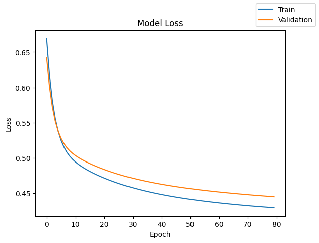

```python
# Plot Loss
plot(history_0, 'loss')
```

**Observatoion**

- Rapid loss decrease in first 10 epochs
- Gradual convergence after epoch 30
- Small, consistent gap between training and validation loss
- Stabilization around epoch 40-50

#### **Recall**

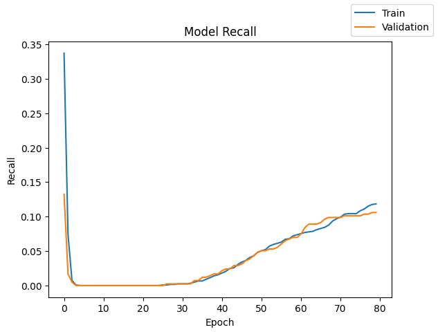

```python
# Plot Recall
plot(history_0, 'recall')
```

**Observation**

- Initial spike followed by drop to near zero
- No improvement from epochs 10-30
- Slow, steady improvement after epoch 30
- Final recall only reaches ~0.10-0.11 (very poor)

**Classification report**

```python
#Predicting the results using 0.5 as the threshold (Train set)
model_0_train_perf, model_0_y_train_pred = model_performance_classification(model_0, X_train, y_train)
print("\nModel Performance on Training Set:")
print(model_0_train_perf.to_string(index=False))
```

```
188/188 ━━━━━━━━━━━━━━━━━━━━ 1s 3ms/step

Model Performance on Training Set:
 Accuracy  Recall  Precision  F1 Score
    0.806   0.806      0.769     0.751
```

```python
#Predicting the results using 0.5 as the threshold (Validation Set)
model_0_val_perf, model_0_y_val_pred = model_performance_classification(model_0, X_val, y_val)
print("\nModel Performance on Validation Set:")
print(model_0_val_perf.to_string(index=False))
```

```
63/63 ━━━━━━━━━━━━━━━━━━━━ 0s 2ms/step

Model Performance on Validation Set:
 Accuracy  Recall  Precision  F1 Score
    0.796   0.796      0.753     0.737
```

**Confusion matrix**

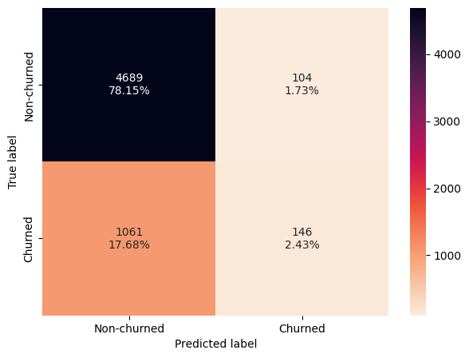

```
 Accuracy  Recall  Precision  F1 Score
    0.806   0.806      0.769     0.751
```

```python
# Confusion matrix for Train set
make_confusion_matrix(y_train, model_0_y_train_pred, model_0_train_perf)
```

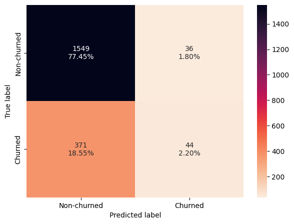

```
 Accuracy  Recall  Precision  F1 Score
    0.796   0.796      0.753     0.737
```

```python
# Confusion matrix for Validation set
make_confusion_matrix(y_val, model_0_y_val_pred, model_0_val_perf)
```

**Observation**

- Training Set:
  - High False Negatives (1061, 17.68%)
  - Low True Positives (146, 2.43%)
  - Accuracy: 0.806, Recall: 0.806
  - F1 Score: 0.751
- Validation Set:
  - Similar pattern of metrics
  - High False Negatives (371, 18.55%)
  - Low True Positives (44, 2.20%)
  - Metrics slightly lower but consistent
- Key Observation:
  - Model favors predicting non-churners
  - Poor performance in identifying churners
  - Good generalization (similar training/validation)
  - High False Negative rate is concerning for churn prediction

## Model Performance Improvement

### Neural Network with Adam Optimizer

**Model 1**

| Model | Model 1 - Adam Optimizer |
| --- | --- |
| **Layers** | 3 with 66, 33 and neurons respectively |
| **Activation function for Hidden layer** | ReLU |
| **Activation for output layer** | Sigmoid |
| **Optimizer** | Adam |
| **Learning rate** | 0.001 |
| **Loss function** | binary_crossentropy |
| **Metrics** | Accuracy, Recall |
| **Epochs** | 80 |
| **Batch Size** | 48 |

```python
# clears the current Keras session, resetting all layers and models previously created, freeing up memory and resources.
backend.clear_session()
#Fixing the seed for random number generators so that we can ensure we receive the same output everytime
np.random.seed(28)
random.seed(28)
tf.random.set_seed(28)
```

```python
# Initialize the Sequential Neural Network
model_1 = Sequential()
# Adding input layer with 66 nodes
# input_dim automatically determined from training data shape
model_1.add(Dense(66, input_dim=X_train.shape[1], activation='relu'))

# Adding hidden layer with 33 nodes (half of previous layer)
# ReLU activation for non-linear transformation
model_1.add(Dense(33, activation='relu'))

# Adding output layer with 1 node for binary classification
# Sigmoid activation to get probability between 0 and 1
model_1.add(Dense(1, activation='sigmoid'))
```

```python
# Compiling with Adam optimizer and binary cross entropy loss function.
optimizer = tf.keras.optimizers.Adam(learning_rate=0.001)
model_1.compile(optimizer=optimizer,
              loss='binary_crossentropy',
              metrics=['accuracy', tf.keras.metrics.Recall()])
```

```python
model_1.summary()
```

```
Model: "sequential"
```

```
┏━━━━━━━━━━━━━━━━━━━━━━━━━━━━━━━━━━━━━━┳━━━━━━━━━━━━━━━━━━━━━━━━━━━━━┳━━━━━━━━━━━━━━━━━┓
┃ Layer (type)                         ┃ Output Shape                ┃         Param # ┃
┡━━━━━━━━━━━━━━━━━━━━━━━━━━━━━━━━━━━━━━╇━━━━━━━━━━━━━━━━━━━━━━━━━━━━━╇━━━━━━━━━━━━━━━━━┩
│ dense (Dense)                        │ (None, 66)                  │             792 │
├──────────────────────────────────────┼─────────────────────────────┼─────────────────┤
│ dense_1 (Dense)                      │ (None, 33)                  │           2,211 │
├──────────────────────────────────────┼─────────────────────────────┼─────────────────┤
│ dense_2 (Dense)                      │ (None, 1)                   │              34 │
└──────────────────────────────────────┴─────────────────────────────┴─────────────────┘
```

```
 Total params: 3,037 (11.86 KB)
```

```
 Trainable params: 3,037 (11.86 KB)
```

```
 Non-trainable params: 0 (0.00 B)
```

```python
# Fitting/Training the Neural Network
start = time.time()
history_1 = model_1.fit(
    X_train, y_train,
    batch_size=batch_size,
    validation_data=(X_val, y_val),  # Using validation set to monitor overfitting
    epochs=epochs,  # Training iterations
    verbose=1    # Show training progress
)
end = time.time()
print(f"Time taken: {end - start} seconds")
```

```
125/125 ━━━━━━━━━━━━━━━━━━━━ 4s 10ms/step - accuracy: 0.7699 - loss: 0.5285 - recall: 0.0591 - val_accuracy: 0.7965 - val_loss: 0.4427 - val_recall: 0.2506
125/125 ━━━━━━━━━━━━━━━━━━━━ 0s 4ms/step - accuracy: 0.8223 - loss: 0.4203 - recall: 0.2146 - val_accuracy: 0.8090 - val_loss: 0.4289 - val_recall: 0.3398
125/125 ━━━━━━━━━━━━━━━━━━━━ 0s 4ms/step - accuracy: 0.8319 - loss: 0.4072 - recall: 0.2664 - val_accuracy: 0.8160 - val_loss: 0.4226 - val_recall: 0.3831
125/125 ━━━━━━━━━━━━━━━━━━━━ 1s 3ms/step - accuracy: 0.8382 - loss: 0.3970 - recall: 0.3088 - val_accuracy: 0.8170 - val_loss: 0.4178 - val_recall: 0.3880
125/125 ━━━━━━━━━━━━━━━━━━━━ 0s 3ms/step - accuracy: 0.8377 - loss: 0.3876 - recall: 0.3212 - val_accuracy: 0.8190 - val_loss: 0.4132 - val_recall: 0.4072
125/125 ━━━━━━━━━━━━━━━━━━━━ 0s 3ms/step - accuracy: 0.8414 - loss: 0.3791 - recall: 0.3517 - val_accuracy: 0.8240 - val_loss: 0.4089 - val_recall: 0.4193
125/125 ━━━━━━━━━━━━━━━━━━━━ 1s 3ms/step - accuracy: 0.8458 - loss: 0.3714 - recall: 0.3667 - val_accuracy: 0.8260 - val_loss: 0.4047 - val_recall: 0.4241
125/125 ━━━━━━━━━━━━━━━━━━━━ 1s 4ms/step - accuracy: 0.8475 - loss: 0.3643 - recall: 0.3805 - val_accuracy: 0.8290 - val_loss: 0.4015 - val_recall: 0.4386
125/125 ━━━━━━━━━━━━━━━━━━━━ 0s 3ms/step - accuracy: 0.8511 - loss: 0.3579 - recall: 0.3938 - val_accuracy: 0.8330 - val_loss: 0.3992 - val_recall: 0.4530
125/125 ━━━━━━━━━━━━━━━━━━━━ 1s 4ms/step - accuracy: 0.8535 - loss: 0.3522 - recall: 0.4042 - val_accuracy: 0.8345 - val_loss: 0.3976 - val_recall: 0.4651
125/125 ━━━━━━━━━━━━━━━━━━━━ 1s 4ms/step - accuracy: 0.8555 - loss: 0.3468 - recall: 0.4172 - val_accuracy: 0.8350 - val_loss: 0.3969 - val_recall: 0.4723
125/125 ━━━━━━━━━━━━━━━━━━━━ 0s 4ms/step - accuracy: 0.8561 - loss: 0.3421 - recall: 0.4225 - val_accuracy: 0.8360 - val_loss: 0.3961 - val_recall: 0.4747
125/125 ━━━━━━━━━━━━━━━━━━━━ 0s 3ms/step - accuracy: 0.8584 - loss: 0.3376 - recall: 0.4346 - val_accuracy: 0.8380 - val_loss: 0.3949 - val_recall: 0.4867
125/125 ━━━━━━━━━━━━━━━━━━━━ 0s 3ms/step - accuracy: 0.8594 - loss: 0.3336 - recall: 0.4415 - val_accuracy: 0.8385 - val_loss: 0.3941 - val_recall: 0.4892
125/125 ━━━━━━━━━━━━━━━━━━━━ 0s 4ms/step - accuracy: 0.8627 - loss: 0.3298 - recall: 0.4567 - val_accuracy: 0.8380 - val_loss: 0.3935 - val_recall: 0.4867
125/125 ━━━━━━━━━━━━━━━━━━━━ 1s 4ms/step - accuracy: 0.8642 - loss: 0.3264 - recall: 0.4650 - val_accuracy: 0.8390 - val_loss: 0.3928 - val_recall: 0.4964
125/125 ━━━━━━━━━━━━━━━━━━━━ 1s 4ms/step - accuracy: 0.8650 - loss: 0.3232 - recall: 0.4676 - val_accuracy: 0.8375 - val_loss: 0.3929 - val_recall: 0.5036
125/125 ━━━━━━━━━━━━━━━━━━━━ 0s 4ms/step - accuracy: 0.8678 - loss: 0.3202 - recall: 0.4841 - val_accuracy: 0.8380 - val_loss: 0.3926 - val_recall: 0.5012
125/125 ━━━━━━━━━━━━━━━━━━━━ 1s 5ms/step - accuracy: 0.8700 - loss: 0.3174 - recall: 0.4868 - val_accuracy: 0.8405 - val_loss: 0.3927 - val_recall: 0.5084
125/125 ━━━━━━━━━━━━━━━━━━━━ 1s 5ms/step - accuracy: 0.8711 - loss: 0.3152 - recall: 0.4929 - val_accuracy: 0.8400 - val_loss: 0.3929 - val_recall: 0.5157
125/125 ━━━━━━━━━━━━━━━━━━━━ 1s 7ms/step - accuracy: 0.8728 - loss: 0.3129 - recall: 0.5033 - val_accuracy: 0.8385 - val_loss: 0.3932 - val_recall: 0.5133
125/125 ━━━━━━━━━━━━━━━━━━━━ 1s 6ms/step - accuracy: 0.8735 - loss: 0.3111 - recall: 0.5068 - val_accuracy: 0.8405 - val_loss: 0.3933 - val_recall: 0.5205
125/125 ━━━━━━━━━━━━━━━━━━━━ 1s 6ms/step - accuracy: 0.8741 - loss: 0.3092 - recall: 0.5082 - val_accuracy: 0.8390 - val_loss: 0.3941 - val_recall: 0.5181
125/125 ━━━━━━━━━━━━━━━━━━━━ 1s 4ms/step - accuracy: 0.8746 - loss: 0.3076 - recall: 0.5135 - val_accuracy: 0.8380 - val_loss: 0.3948 - val_recall: 0.5205
125/125 ━━━━━━━━━━━━━━━━━━━━ 0s 3ms/step - accuracy: 0.8738 - loss: 0.3062 - recall: 0.5116 - val_accuracy: 0.8380 - val_loss: 0.3951 - val_recall: 0.5181
125/125 ━━━━━━━━━━━━━━━━━━━━ 1s 4ms/step - accuracy: 0.8746 - loss: 0.3045 - recall: 0.5140 - val_accuracy: 0.8370 - val_loss: 0.3962 - val_recall: 0.5157
```

[output cut: 55 more lines]

#### **Loss Function**

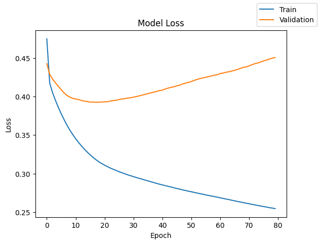

```python
# Plot Loss
plot(history_1, 'loss')
```

**Observation**

- Training loss steadily decreases
- Validation loss initially drops but starts increasing after epoch 20
- Growing gap between training and validation loss
- Clear overfitting pattern

#### **Recall**

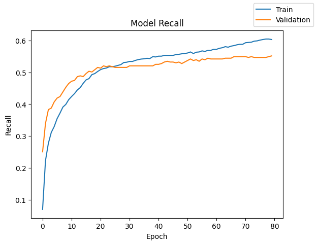

```python
# Plot Recall
plot(history_1, 'recall')
```

**Observation**

- Rapid recall improvement until epoch 20
- Training recall continues climbing to ~0.60
- Validation recall plateaus at ~0.52
- Increasing gap between train/validation after epoch 30
- Training/validation divergence indicating overfitting

```
63/63 ━━━━━━━━━━━━━━━━━━━━ 0s 5ms/step
Best Threshold=0.162, G-Mean=0.742
```

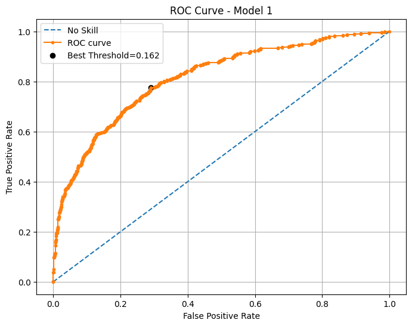

```
(0.16197163, 0.7417753716508534)
```

```python
# ROC
plot_roc_and_find_optimal_threshold(model_1, X_val, y_val, 'Model 1')
```

**Classification report**

```python
#Predicting the results using optimal threshold (Train set)
# Not using the optimal threshold from ROC, the 0.5 is better
optimal_threshold = 0.5
model_1_train_perf, model_1_y_train_pred = model_performance_classification(model_1, X_train, y_train, optimal_threshold)
print("\nModel Performance on Training Set:")
print(model_1_train_perf.to_string(index=False))
```

```
188/188 ━━━━━━━━━━━━━━━━━━━━ 0s 2ms/step

Model Performance on Training Set:
 Accuracy  Recall  Precision  F1 Score
    0.890   0.890      0.889     0.890
```

```python
#Predicting the results using optimal threshold (Validation Set)
model_1_val_perf, model_1_y_val_pred = model_performance_classification(model_1, X_val, y_val, optimal_threshold)
print("\nModel Performance on Validation Set:")
print(model_1_val_perf.to_string(index=False))
```

```
63/63 ━━━━━━━━━━━━━━━━━━━━ 0s 3ms/step

Model Performance on Validation Set:
 Accuracy  Recall  Precision  F1 Score
    0.815   0.815      0.814     0.814
```

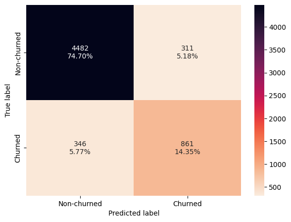

```
 Accuracy  Recall  Precision  F1 Score
    0.890   0.890      0.889     0.890
```

```python
# Confusion matrix for Train set
make_confusion_matrix(y_train, model_1_y_train_pred, model_1_train_perf)
```

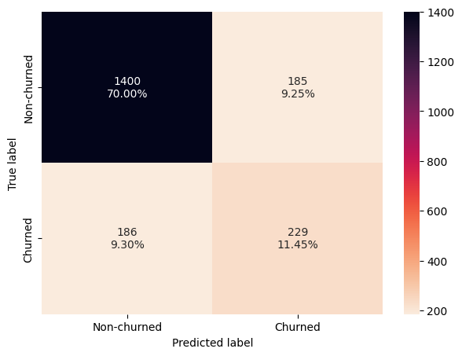

```
 Accuracy  Recall  Precision  F1 Score
    0.815   0.815      0.814     0.814
```

```python
# Confusion matrix for Validation set
make_confusion_matrix(y_val, model_1_y_val_pred, model_1_val_perf)
```

### Neural Network with Adam Optimizer and Dropout

**Model 2**

| Model | Model 2 - Adam Optimizer and Dropout |
| --- | --- |
| **Hidden layers** | 2 with 33 and 16 neurons respectively |
| **Activation function for Hidden layer** | ReLU |
| **Activation for output layer** | Sigmoid |
| **Optimizer** | Adam |
| **Learning rate** | 0.001 |
| **Loss function** | binary_crossentropy |
| **Metrics** | Accuracy, Recall |
| **Epochs** | 80 |
| **Batch Size** | 48 |
| **Dropout** | 20% after before First and Second hidden layer |

```python
# clears the current Keras session, resetting all layers and models previously created, freeing up memory and resources.
backend.clear_session()
#Fixing the seed for random number generators so that we can ensure we receive the same output everytime
np.random.seed(28)
random.seed(28)
tf.random.set_seed(28)
```

```python
# Initialize the Sequential Neural Network
model_2 = Sequential()

# Adding input layer with 66 nodes (6x number of features)
# input_dim automatically determined from training data shape
model_2.add(Dense(66, activation='relu', input_dim=X_train.shape[1]))

# Add dropout layer to prevent overfitting (20% dropout rate)
model_2.add(Dropout(0.2))

# First hidden layer with 33 nodes (half of previous layer)
model_2.add(Dense(33, activation='relu'))

# Another dropout layer for regularization
model_2.add(Dropout(0.2))

# Second hidden layer with 16 nodes (~half of previous layer)
model_2.add(Dense(16, activation='relu'))

# Output layer with sigmoid activation for binary classification
# Single node outputs probability between 0 and 1
model_2.add(Dense(1, activation='sigmoid'))
```

```python
# Compiling with Adam optimizer and binary cross entropy loss function.
optimizer = tf.keras.optimizers.Adam(learning_rate=0.001)
model_2.compile(optimizer=optimizer,
              loss='binary_crossentropy',
              metrics=['accuracy', tf.keras.metrics.Recall()])
```

```python
model_2.summary()
```

```
Model: "sequential"
```

```
┏━━━━━━━━━━━━━━━━━━━━━━━━━━━━━━━━━━━━━━┳━━━━━━━━━━━━━━━━━━━━━━━━━━━━━┳━━━━━━━━━━━━━━━━━┓
┃ Layer (type)                         ┃ Output Shape                ┃         Param # ┃
┡━━━━━━━━━━━━━━━━━━━━━━━━━━━━━━━━━━━━━━╇━━━━━━━━━━━━━━━━━━━━━━━━━━━━━╇━━━━━━━━━━━━━━━━━┩
│ dense (Dense)                        │ (None, 66)                  │             792 │
├──────────────────────────────────────┼─────────────────────────────┼─────────────────┤
│ dropout (Dropout)                    │ (None, 66)                  │               0 │
├──────────────────────────────────────┼─────────────────────────────┼─────────────────┤
│ dense_1 (Dense)                      │ (None, 33)                  │           2,211 │
├──────────────────────────────────────┼─────────────────────────────┼─────────────────┤
│ dropout_1 (Dropout)                  │ (None, 33)                  │               0 │
├──────────────────────────────────────┼─────────────────────────────┼─────────────────┤
│ dense_2 (Dense)                      │ (None, 16)                  │             544 │
├──────────────────────────────────────┼─────────────────────────────┼─────────────────┤
│ dense_3 (Dense)                      │ (None, 1)                   │              17 │
└──────────────────────────────────────┴─────────────────────────────┴─────────────────┘
```

```
 Total params: 3,564 (13.92 KB)
```

```
 Trainable params: 3,564 (13.92 KB)
```

```
 Non-trainable params: 0 (0.00 B)
```

```python
# Fitting/Training the Neural Network
start = time.time()
history_2 = model_2.fit(
    X_train, y_train,
    batch_size=batch_size,
    validation_data=(X_val, y_val),  # Using validation set to monitor overfitting
    epochs=epochs,  # Training iterations
    verbose=1    # Show training progress
)
end = time.time()
print(f"Time taken: {end - start} seconds")
```

```
125/125 ━━━━━━━━━━━━━━━━━━━━ 4s 10ms/step - accuracy: 0.8060 - loss: 0.5075 - recall: 1.7585e-04 - val_accuracy: 0.7980 - val_loss: 0.4442 - val_recall: 0.0843
125/125 ━━━━━━━━━━━━━━━━━━━━ 3s 4ms/step - accuracy: 0.8082 - loss: 0.4414 - recall: 0.0406 - val_accuracy: 0.8080 - val_loss: 0.4342 - val_recall: 0.2578
125/125 ━━━━━━━━━━━━━━━━━━━━ 1s 4ms/step - accuracy: 0.8157 - loss: 0.4342 - recall: 0.1453 - val_accuracy: 0.8125 - val_loss: 0.4305 - val_recall: 0.3108
125/125 ━━━━━━━━━━━━━━━━━━━━ 1s 4ms/step - accuracy: 0.8190 - loss: 0.4234 - recall: 0.1734 - val_accuracy: 0.8195 - val_loss: 0.4236 - val_recall: 0.3446
125/125 ━━━━━━━━━━━━━━━━━━━━ 1s 4ms/step - accuracy: 0.8258 - loss: 0.4162 - recall: 0.2374 - val_accuracy: 0.8160 - val_loss: 0.4186 - val_recall: 0.3855
125/125 ━━━━━━━━━━━━━━━━━━━━ 1s 6ms/step - accuracy: 0.8283 - loss: 0.4103 - recall: 0.2767 - val_accuracy: 0.8140 - val_loss: 0.4153 - val_recall: 0.3952
125/125 ━━━━━━━━━━━━━━━━━━━━ 1s 5ms/step - accuracy: 0.8368 - loss: 0.4052 - recall: 0.3148 - val_accuracy: 0.8230 - val_loss: 0.4067 - val_recall: 0.3880
125/125 ━━━━━━━━━━━━━━━━━━━━ 1s 6ms/step - accuracy: 0.8347 - loss: 0.3964 - recall: 0.3197 - val_accuracy: 0.8260 - val_loss: 0.4017 - val_recall: 0.4024
125/125 ━━━━━━━━━━━━━━━━━━━━ 1s 4ms/step - accuracy: 0.8370 - loss: 0.3891 - recall: 0.3349 - val_accuracy: 0.8315 - val_loss: 0.3969 - val_recall: 0.4241
125/125 ━━━━━━━━━━━━━━━━━━━━ 1s 4ms/step - accuracy: 0.8434 - loss: 0.3827 - recall: 0.3784 - val_accuracy: 0.8375 - val_loss: 0.3909 - val_recall: 0.4482
125/125 ━━━━━━━━━━━━━━━━━━━━ 1s 4ms/step - accuracy: 0.8472 - loss: 0.3807 - recall: 0.3846 - val_accuracy: 0.8415 - val_loss: 0.3900 - val_recall: 0.4699
125/125 ━━━━━━━━━━━━━━━━━━━━ 0s 4ms/step - accuracy: 0.8471 - loss: 0.3788 - recall: 0.3899 - val_accuracy: 0.8365 - val_loss: 0.3883 - val_recall: 0.4506
125/125 ━━━━━━━━━━━━━━━━━━━━ 1s 4ms/step - accuracy: 0.8484 - loss: 0.3643 - recall: 0.4126 - val_accuracy: 0.8385 - val_loss: 0.3897 - val_recall: 0.4723
125/125 ━━━━━━━━━━━━━━━━━━━━ 1s 4ms/step - accuracy: 0.8519 - loss: 0.3683 - recall: 0.4148 - val_accuracy: 0.8435 - val_loss: 0.3839 - val_recall: 0.4651
125/125 ━━━━━━━━━━━━━━━━━━━━ 1s 4ms/step - accuracy: 0.8527 - loss: 0.3574 - recall: 0.4186 - val_accuracy: 0.8430 - val_loss: 0.3836 - val_recall: 0.4747
125/125 ━━━━━━━━━━━━━━━━━━━━ 0s 4ms/step - accuracy: 0.8611 - loss: 0.3522 - recall: 0.4508 - val_accuracy: 0.8425 - val_loss: 0.3803 - val_recall: 0.4554
125/125 ━━━━━━━━━━━━━━━━━━━━ 1s 4ms/step - accuracy: 0.8622 - loss: 0.3536 - recall: 0.4476 - val_accuracy: 0.8445 - val_loss: 0.3780 - val_recall: 0.4651
125/125 ━━━━━━━━━━━━━━━━━━━━ 0s 4ms/step - accuracy: 0.8647 - loss: 0.3502 - recall: 0.4740 - val_accuracy: 0.8390 - val_loss: 0.3803 - val_recall: 0.4771
125/125 ━━━━━━━━━━━━━━━━━━━━ 1s 4ms/step - accuracy: 0.8638 - loss: 0.3507 - recall: 0.4727 - val_accuracy: 0.8450 - val_loss: 0.3771 - val_recall: 0.4771
125/125 ━━━━━━━━━━━━━━━━━━━━ 0s 4ms/step - accuracy: 0.8608 - loss: 0.3438 - recall: 0.4505 - val_accuracy: 0.8430 - val_loss: 0.3772 - val_recall: 0.4916
125/125 ━━━━━━━━━━━━━━━━━━━━ 1s 4ms/step - accuracy: 0.8637 - loss: 0.3442 - recall: 0.4736 - val_accuracy: 0.8475 - val_loss: 0.3749 - val_recall: 0.4651
125/125 ━━━━━━━━━━━━━━━━━━━━ 0s 4ms/step - accuracy: 0.8599 - loss: 0.3416 - recall: 0.4699 - val_accuracy: 0.8450 - val_loss: 0.3770 - val_recall: 0.4964
125/125 ━━━━━━━━━━━━━━━━━━━━ 1s 4ms/step - accuracy: 0.8643 - loss: 0.3401 - recall: 0.4774 - val_accuracy: 0.8440 - val_loss: 0.3778 - val_recall: 0.4795
125/125 ━━━━━━━━━━━━━━━━━━━━ 0s 4ms/step - accuracy: 0.8658 - loss: 0.3374 - recall: 0.4753 - val_accuracy: 0.8410 - val_loss: 0.3768 - val_recall: 0.4699
125/125 ━━━━━━━━━━━━━━━━━━━━ 1s 4ms/step - accuracy: 0.8658 - loss: 0.3306 - recall: 0.4809 - val_accuracy: 0.8430 - val_loss: 0.3759 - val_recall: 0.4675
125/125 ━━━━━━━━━━━━━━━━━━━━ 1s 4ms/step - accuracy: 0.8650 - loss: 0.3338 - recall: 0.4664 - val_accuracy: 0.8420 - val_loss: 0.3751 - val_recall: 0.4675
```

[output cut: 55 more lines]